### Author: Chandrasekaran Krishna Mohan

# Project 1: Applied Statistics

This is the first project in the AIML course offered by Great Learning. The project is split into 3 parts covering probability basics, EDA, visualisation and inferential statistics.

**Part 1:** Contains 6 questions on probabiity which require detailed answers including assumptions, explanations and calculations  
**Part 2:** Contains a dataset from SPORTS domain on which EDA needs to be performed to arrive at a conclusion on performance  
**Part 3:** Contains a dataset from STARTUP ECOSYSTEM from which statistical inferences need to be derived

Let us begin with **Part 1**

## Part 1: Question Based

### Q1: Please refer the table below to answer below questions

[output not shown]

**1.1** Refer to the above table and find the joint probability of the people who planned to purchase and actually placed an order.

This is a simple probability calculation where P(planned to purchase and actually placed order) is the proportion of people who planned to purchase and placed order (400) with respect to total number (2000)

```python
print("P(planned to purchase and actually placed order)= %.2f"  %(400/2000))
```

```
P(planned to purchase and actually placed order)= 0.20
```

**1.2** Refer to the above table and find the joint probability of the people who planned to purchase and actually placed an order, given that people planned to purchase

This is a conditional probability where P(planned to purchase and actually placed order given planned to purchase) = P(planned to purchase and actually placed order)/ P(planned to purchase) = (400/2000)/(500/2000)

```python
print("P(planned to purchase and actually placed order given planned to purchase) = P(planned to purchase and actually placed order)/ P(planned to purchase)")
print("P(planned to purchase and actually placed order given planned to purchase) = %.2f" %(400/500))
```

```
P(planned to purchase and actually placed order given planned to purchase) = P(planned to purchase and actually placed order)/ P(planned to purchase)
P(planned to purchase and actually placed order given planned to purchase) = 0.80
```

### Q2: An electrical manufacturing company conducts quality checks at specified periods on the products it manufactures. Historically, the failure rate for the manufactured item is 5%. Suppose a random sample of 10 manufactured items is selected. Answer the following questions

**2.1** Probability that none of the items are defective?

This is an example of a binomial event where the products can either be defective or not defective.

> p = P(sample is defective) = 5% = 0.05  
> n = Number of samples = 10

Hence the probability distribution for this can be obtained via the stats.binom.pmf or stats.binom.cdf functions with n=10 and p=0.05, depending on whether we need cumulative or point probability

In mathematical terms, the formula would be given as below for the probability of getting x defective items, for a given n & p

$$ P(X=x) = \binom{n}{x}p^x (1-p)^{n-x} $$

```python
import numpy as np
import pandas as pd
import matplotlib.pyplot as plt
%matplotlib inline
import seaborn as sns
import scipy.stats as stats
p = 0.05 # probability that sample is defective
n = 10 # number of samples
x= np.arange(0,11) # array containing all possible success values
prob_dist = stats.binom.pmf(x,n,p)   #calculate the probability distribution
print("Probability distribution array", prob_dist)   # display all the probabiity distribution values
print("\n")
print("Probability that none of the items are defective  = %.3f" %(prob_dist[0]))
```

```
Probability distribution array [5.98736939e-01 3.15124705e-01 7.46347985e-02 1.04750594e-02
 9.64808106e-04 6.09352488e-05 2.67259863e-06 8.03789063e-08
 1.58642578e-09 1.85546875e-11 9.76562500e-14]


Probability that none of the items are defective  = 0.599
```

**2.2** Probability that exactly one of the items is defective?

```python
print("Probability that one of the items is defective  = %.3f" %prob_dist[1])
```

```
Probability that one of the items is defective  = 0.315
```

**2.3** Probability that two or fewer of the items are defective?

> Probability that two or fewer of the items is defective = Probability (0 defective or 1 defective or 2 defectives)

Since, these are mutually exclusive events,

> Probability that two or fewer of the items is defective = Probability (0 defective) + Probability (1 defective) + Probability (2 defectives)

```python
print("Probability that two or fewer items are defective  = %.3f" %prob_dist[0:3].sum())
```

```
Probability that two or fewer items are defective  = 0.988
```

**2.4** Probability that three or more of the items are defective ?

Applying same additive rule as above:

```python
print("Probability that three or more items are defective  = %.3f" %prob_dist[3:11].sum())
```

```
Probability that three or more items are defective  = 0.012
```

### Q3: A car salesman sells on an average 3 cars per week.

**3.1** Probability that in a given week he will sell some cars

This experiment, with no restriction on the maximum number of "trials/events" can be described by Poisson Distribution.

> lambda = Average sales rate = 3 cars/week

Hence the probability distribution for this can be obtained via the stats.poisson.pmf or stats.poissonm.cdf functions with lambda=3, depending on whether we need cumulative or point probability

In mathematical terms, the formula would be given as below for the probability of selling x cars in a week, for a given $\lambda$

$$ P(X=x) = \frac{\lambda^x e^{-\lambda}}{x!} $$

```python
avg_rate = 3 # lambda
x= np.arange(0,20) # array containing possible success values, upto 20
prob_dist = stats.poisson.pmf(x,avg_rate) # calculating the probaility distribution
print("Probability distribution array", prob_dist)
print("\n")
print("Probability that he sells some cars = 1- Probability that he sells no cars = %.3f" %(1-prob_dist[0]))
```

```
Probability distribution array [4.97870684e-02 1.49361205e-01 2.24041808e-01 2.24041808e-01
 1.68031356e-01 1.00818813e-01 5.04094067e-02 2.16040315e-02
 8.10151179e-03 2.70050393e-03 8.10151179e-04 2.20950322e-04
 5.52375804e-05 1.27471339e-05 2.73152870e-06 5.46305740e-07
 1.02432326e-07 1.80762929e-08 3.01271548e-09 4.75691918e-10]


Probability that he sells some cars = 1- Probability that he sells no cars = 0.950
```

**3.2** Probability that in a given week he will sell 2 or more but less than 5 cars.

Applying the addition rule, since selling 2 cars or 3 cars or 4 cars are all mutually exclusive events:

```python
print("Probability that he sells 2 or more but less than 5 cars = %.3f" %(prob_dist[2:5].sum()))
```

```
Probability that he sells 2 or more but less than 5 cars = 0.616
```

**3.3** Plot the poisson distribution function for cumulative probability of cars sold per-week vs number of cars sold perweek.

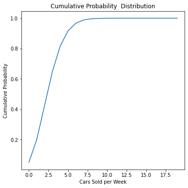

```python
fig=plt.figure()
plt.figure(figsize=(6,6))
prob_dist_cum = stats.poisson.cdf(x,avg_rate) #calculate the cumulative probability distribution
plt.plot(x, prob_dist_cum)
plt.title("Cumulative Probability  Distribution")
plt.ylabel("Cumulative Probability")
plt.xlabel("Cars Sold per Week")
```

### Q4: Accuracy in understanding orders for a speech based bot at a restaurant is important for the Company X which has designed, marketed and launched the product for a contactless delivery due to the COVID-19 pandemic. Recognition accuracy that measures the percentage of orders that are taken correctly is 86.8%. Suppose that you place order with the bot and two friends of yours independently place orders with the same bot. Answer the following questions

**4.1** What is the probability that all three orders will be recognised correctly?

This experiment is again a binomial distribution with

> p = 0.868  
> n = 3

Hence the probability distribution for this can be obtained via the stats.binom.pmf or stats.binom.cdf functions with n=3 and p=0.868, depending on whether we need cumulative or point probability

In mathematical terms, the formula would be given as below for the probability of getting x orders correct, for a given n & p

$$ P(X=x) = \binom{n}{x}p^x (1-p)^{n-x} $$

```python
x=np.arange(0,4)
p=0.868
n=3
binom_dist = stats.binom.pmf(x,n,p)
print("Probability that all three orders will be recognised correctly = %.3f" %binom_dist[3])
```

```
Probability that all three orders will be recognised correctly = 0.654
```

**4.2** What is the probability that none of the three orders will be recognised correctly?

```python
print("Probability that none of the orders will be recognised correctly = %.3f" %binom_dist[0])
```

```
Probability that none of the orders will be recognised correctly = 0.002
```

**4.3** What is the probability that at least two of the three orders will be recognised correctly?

Appying addition rule here since probability of getting atleast 2 orders right is same as sum of probability of 2 orders right and probability of 3 orders right

```python
print("Probability that atleast 2 out of 3 orders will be recognised correctly = %.3f" %(binom_dist[2]+binom_dist[3]))
```

```
Probability that atleast 2 out of 3 orders will be recognised correctly = 0.952
```

### Q5: A group of 300 professionals sat for a competitive exam. The results show the information of marks obtained by them have a mean of 60 and a standard deviation of 12. The pattern of marks follows a normal distribution. Answer the following questions

**5.1** What is the percentage of students who score more than 80.

As mentioned in the question, this is a normal distribution with

> loc = mean = 60  
> scale = standard deviation = 12

Hence, the probability distribution can be obtained by using stats.norm.cdf function, as per the value mentioned

In mathematical terms, the formula would be given as below for the probability mass function is given by, for a given $\mu$ and $\sigma$ $$f(x) = \frac{1}{\sigma\sqrt{2\pi}} \exp\left( -\frac{1}{2}\left(\frac{x-\mu}{\sigma}\right)^{\!2}\,\right) $$

```python
loc = 60
scale =12
print ("Percentage of students scored > 80 = %0.2f%%" %((1-stats.norm.cdf(80,loc,scale))*100))
```

```
Percentage of students scored > 80 = 4.78%
```

**5.2** What is the percentage of students who score less than 50

```python
print ("Percentage of students scored < 50 = %0.2f%%" %(stats.norm.cdf(50,loc,scale)*100))
```

```
Percentage of students scored < 50 = 20.23%
```

**5.3** What should be the distinction mark if the highest 10% of students are to be awarded distinction?

Highest 10% of students implies we need to find the z10 that will corresponding to P(z>z10)=10%. For this, we can use the inverse distribution function

```python
p=0.1
z10 = stats.norm.isf(0.1)
print("z10 = %0.3f" %z10)
x = z10*scale + loc
print("The cut-off for distinction should be = %0.2f%%" %x)
```

```
z10 = 1.282
The cut-off for distinction should be = 75.38%
```

### Q6: Explain 1 real life industry scenario [other than the ones mentioned above] where you can use the concepts learnt in this module of Applied statistics to get a data driven business solution.

The concept of Bayes Theorem can be very well applied to Spam Filters for e-mail. The filters fundamentally follow Bayes Theorem in detecting if a mail is spam or not basis the words contained in the e-mail. As per Bayes Theorem, the below probabilities will be available apriori basis sample data

> P(Spam) = probability that a given e-mail is spam (based on hisotrical data)  
> P(Word|Spam) = probabiity that a given word occurs in a spam e-mail  
> P(Ham) = probability that a given e-mail is not spam (ham ; based on historical data)  
> P(Word|Ham) = probaility that a given word occurs in ham e-mail

From Bayes Theorem, we know that $$ P(Spam|Word) = \frac{P(Word|Spam)*P(Spam)}{P(Word)}\\ $$

We also know that since an e-mail being spam or ham are mutually exclusive events $$ P(Word) = {P(Word\cap Spam) + P(Word\cap Ham)}\\ $$

which in turn can be written as $$ P(Word) = {P(Word|Spam)*P(Spam) + P(Word|Ham)*P(Ham)} $$

Hence, $$ P(Spam|Word) = \frac{P(Word|Spam)*P(Spam)}{P(Word|Spam)*P(Spam)+P(Word|Ham)*P(Ham)}\\ $$

The data on the apriori probabilities can also be updated as we process more and more e-mails in the above system. By setting a probability threshold, we can classify e-mails as Spam or Ham. Therefore, just by knowing hte proportions of overall e-mails that are spam and ham, along with the probability of a particular word occuring in them, we can assign probability to and classify mails as Spam or Ham.

## Part 2: Project Based

**Domain:** Sports

**Context:** Company X manages the men's top professional basketball division of the American league system. The dataset contains information on all the teams that have participated in all the past tournaments. It has data about how many baskets each team scored, conceded, how many times they came within the first 2 positions, how many tournaments they have qualified, their best position in the past, etc.

**Data Description:** Basketball.csv - The data set contains information on all the teams so far participated in all the past tournaments.

**Attribute Information:**

1. **Team:** Team's name
2. **Tournament:** Number of played tournaments
3. **Score:** Team's score so far
4. **PlayedGames:** Games played by the team so far
5. **WonGames:** Games won by the team so far
6. **DrawnGames:** Games drawn by the team so far
7. **LostGames:** Games lost by the team so far
8. **BasketScored:** Basket scored by the team so far
9. **BasketGiven:** Basket scored against the team so far
10. **TournamentChampion:** How many times the team was a champion of the tournaments so far
11. **Runner-up:** How many times the team was a runners-up of the tournaments so far
12. **TeamLaunch:** Year the team was launched on professional basketball
13. **HighestPositionHeld:** Highest position held by the team amongst all the tournaments played

**Project Objective:** Company’s management wants to invest on proposal on managing some of the best teams in the league. The analytics department has been assigned with a task of creating a report on the performance shown by the teams. Some of the older teams are already in contract with competitors. Hence Company X wants to understand which teams they can approach which will be a deal win for them.

```python
# importing packages
#import matplotlib.style as style; style.use('fivethirtyeight')
from datetime import datetime, date
import statsmodels.api         as     sm
from   statsmodels.formula.api import ols
from   statsmodels.stats.anova import anova_lm
```

```python
# Read the data & check the first 5 rows
df = pd.read_csv("DS - Part2 - Basketball.csv")
df.head(5)
```

|  | Team | Tournament | Score | PlayedGames | WonGames | DrawnGames | LostGames | BasketScored | BasketGiven | TournamentChampion | Runner-up | TeamLaunch | HighestPositionHeld |
| --- | --- | --- | --- | --- | --- | --- | --- | --- | --- | --- | --- | --- | --- |
| 0 | Team 1 | 86 | 4385 | 2762 | 1647 | 552 | 563 | 5947 | 3140 | 33 | 23 | 1929 | 1 |
| 1 | Team 2 | 86 | 4262 | 2762 | 1581 | 573 | 608 | 5900 | 3114 | 25 | 25 | 1929 | 1 |
| 2 | Team 3 | 80 | 3442 | 2614 | 1241 | 598 | 775 | 4534 | 3309 | 10 | 8 | 1929 | 1 |
| 3 | Team 4 | 82 | 3386 | 2664 | 1187 | 616 | 861 | 4398 | 3469 | 6 | 6 | 1931to32 | 1 |
| 4 | Team 5 | 86 | 3368 | 2762 | 1209 | 633 | 920 | 4631 | 3700 | 8 | 7 | 1929 | 1 |

```python
# number of entries in the dataset
df.shape
```

```
(61, 13)
```

```python
# check the data types of each attribute, followed by the non-zero entry count
df.dtypes
```

```
Team                   object
Tournament              int64
Score                  object
PlayedGames            object
WonGames               object
DrawnGames             object
LostGames              object
BasketScored           object
BasketGiven            object
TournamentChampion     object
Runner-up              object
TeamLaunch             object
HighestPositionHeld     int64
dtype: object
```

We see that there are total of 61 entries in the dataset and 13 attributes. Of these 13 attributes, there are only 2 attributes that are numeric whie the rest are of type object. This means we will have to check if there are any odd entries in these columns

```python
df.info()
```

```
<class 'pandas.core.frame.DataFrame'>
RangeIndex: 61 entries, 0 to 60
Data columns (total 13 columns):
 #   Column               Non-Null Count  Dtype
---  ------               --------------  -----
 0   Team                 61 non-null     object
 1   Tournament           61 non-null     int64
 2   Score                61 non-null     object
 3   PlayedGames          61 non-null     object
 4   WonGames             61 non-null     object
 5   DrawnGames           61 non-null     object
 6   LostGames            61 non-null     object
 7   BasketScored         61 non-null     object
 8   BasketGiven          61 non-null     object
 9   TournamentChampion   61 non-null     object
 10  Runner-up            61 non-null     object
 11  TeamLaunch           61 non-null     object
 12  HighestPositionHeld  61 non-null     int64
dtypes: int64(2), object(11)
memory usage: 6.3+ KB
```

All columns have non-null entries throughout.

```python
# data summary for all attributes
df.describe(include='all').T
```

|  | count | unique | top | freq | mean | std | min | 25% | 50% | 75% | max |
| --- | --- | --- | --- | --- | --- | --- | --- | --- | --- | --- | --- |
| Team | 61 | 61 | Team 56 | 1 | NaN | NaN | NaN | NaN | NaN | NaN | NaN |
| Tournament | 61.0 | NaN | NaN | NaN | 24.0 | 26.827225 | 1.0 | 4.0 | 12.0 | 38.0 | 86.0 |
| Score | 61 | 61 | 1174 | 1 | NaN | NaN | NaN | NaN | NaN | NaN | NaN |
| PlayedGames | 61 | 53 | 30 | 3 | NaN | NaN | NaN | NaN | NaN | NaN | NaN |
| WonGames | 61 | 59 | 7 | 2 | NaN | NaN | NaN | NaN | NaN | NaN | NaN |
| DrawnGames | 61 | 57 | 14 | 2 | NaN | NaN | NaN | NaN | NaN | NaN | NaN |
| LostGames | 61 | 56 | 37 | 3 | NaN | NaN | NaN | NaN | NaN | NaN | NaN |
| BasketScored | 61 | 60 | 70 | 2 | NaN | NaN | NaN | NaN | NaN | NaN | NaN |
| BasketGiven | 61 | 61 | 3230 | 1 | NaN | NaN | NaN | NaN | NaN | NaN | NaN |
| TournamentChampion | 61 | 8 | - | 52 | NaN | NaN | NaN | NaN | NaN | NaN | NaN |
| Runner-up | 61 | 10 | - | 48 | NaN | NaN | NaN | NaN | NaN | NaN | NaN |
| TeamLaunch | 61 | 47 | 1929 | 10 | NaN | NaN | NaN | NaN | NaN | NaN | NaN |
| HighestPositionHeld | 61.0 | NaN | NaN | NaN | 7.081967 | 5.276663 | 1.0 | 3.0 | 6.0 | 10.0 | 20.0 |

```python
# check the last 5 entries in the dataset
df.tail(5)
```

|  | Team | Tournament | Score | PlayedGames | WonGames | DrawnGames | LostGames | BasketScored | BasketGiven | TournamentChampion | Runner-up | TeamLaunch | HighestPositionHeld |
| --- | --- | --- | --- | --- | --- | --- | --- | --- | --- | --- | --- | --- | --- |
| 56 | Team 57 | 1 | 34 | 38 | 8 | 10 | 20 | 38 | 66 | - | - | 2009-10 | 20 |
| 57 | Team 58 | 1 | 22 | 30 | 7 | 8 | 15 | 37 | 57 | - | - | 1956-57 | 16 |
| 58 | Team 59 | 1 | 19 | 30 | 7 | 5 | 18 | 51 | 85 | - | - | 1951~52 | 16 |
| 59 | Team 60 | 1 | 14 | 30 | 5 | 4 | 21 | 34 | 65 | - | - | 1955-56 | 15 |
| 60 | Team 61 | 1 | - | - | - | - | - | - | - | - | - | 2017~18 | 9 |

```python
# creating a deep copy of the dataframe
df1 = df.copy(deep=True)
```

Now we replace all "-" entries with 0.

```python
df1.replace('-',np.nan, inplace = True)
df1 = df1.fillna(0)
```

```python
df1.info()
```

```
<class 'pandas.core.frame.DataFrame'>
RangeIndex: 61 entries, 0 to 60
Data columns (total 13 columns):
 #   Column               Non-Null Count  Dtype
---  ------               --------------  -----
 0   Team                 61 non-null     object
 1   Tournament           61 non-null     int64
 2   Score                61 non-null     object
 3   PlayedGames          61 non-null     object
 4   WonGames             61 non-null     object
 5   DrawnGames           61 non-null     object
 6   LostGames            61 non-null     object
 7   BasketScored         61 non-null     object
 8   BasketGiven          61 non-null     object
 9   TournamentChampion   61 non-null     object
 10  Runner-up            61 non-null     object
 11  TeamLaunch           61 non-null     object
 12  HighestPositionHeld  61 non-null     int64
dtypes: int64(2), object(11)
memory usage: 6.3+ KB
```

```python
# convert object dtype attributes to int
df1= df1.astype({"Score": np.int64, "PlayedGames": np.int64, "WonGames": np.int64,
                 "DrawnGames": np.int64, "LostGames": np.int64, "BasketScored": np.int64,
                "BasketGiven": np.int64,"TournamentChampion": np.int64, "Runner-up": np.int64})
```

```python
df1.info()
```

```
<class 'pandas.core.frame.DataFrame'>
RangeIndex: 61 entries, 0 to 60
Data columns (total 13 columns):
 #   Column               Non-Null Count  Dtype
---  ------               --------------  -----
 0   Team                 61 non-null     object
 1   Tournament           61 non-null     int64
 2   Score                61 non-null     int64
 3   PlayedGames          61 non-null     int64
 4   WonGames             61 non-null     int64
 5   DrawnGames           61 non-null     int64
 6   LostGames            61 non-null     int64
 7   BasketScored         61 non-null     int64
 8   BasketGiven          61 non-null     int64
 9   TournamentChampion   61 non-null     int64
 10  Runner-up            61 non-null     int64
 11  TeamLaunch           61 non-null     object
 12  HighestPositionHeld  61 non-null     int64
dtypes: int64(11), object(2)
memory usage: 6.3+ KB
```

Now, we have converted all the numeric columns into integer datatypes.  
We move to the TeamLaunch attribute. This has multiple typesof anomalous data as mentioned below:

- xxxxtoyy
- xxxx-yy
- xxxx~yy
- xxxx_yy

We will now remove these using a lambda function and retain only the first year (in a combined year entry) in a separate column called YearLaunch and create a column called Age which contains the age of the team in years

```python
def comb2single(x):
    if 'to' in x:
        return x.split('to')[0]
    elif '-' in x:
        return x.split('-')[0]
    elif '~' in x:
        return x.split('~')[0]
    elif '_' in x:
        return x.split('_')[0]
    else:
        return x

df1["YearLaunch"] = df1["TeamLaunch"].apply(comb2single)
df1 = df1.astype({"YearLaunch": np.int64}) # convert YearLaunch to datatype int
today = date.today()
df1["Age"] = df1["YearLaunch"].apply(lambda x: today.year-x) # subtract YearLaunch from current year to get team age
```

```python
df1.head()
```

|  | Team | Tournament | Score | PlayedGames | WonGames | DrawnGames | LostGames | BasketScored | BasketGiven | TournamentChampion | Runner-up | TeamLaunch | HighestPositionHeld | YearLaunch | Age |
| --- | --- | --- | --- | --- | --- | --- | --- | --- | --- | --- | --- | --- | --- | --- | --- |
| 0 | Team 1 | 86 | 4385 | 2762 | 1647 | 552 | 563 | 5947 | 3140 | 33 | 23 | 1929 | 1 | 1929 | 92 |
| 1 | Team 2 | 86 | 4262 | 2762 | 1581 | 573 | 608 | 5900 | 3114 | 25 | 25 | 1929 | 1 | 1929 | 92 |
| 2 | Team 3 | 80 | 3442 | 2614 | 1241 | 598 | 775 | 4534 | 3309 | 10 | 8 | 1929 | 1 | 1929 | 92 |
| 3 | Team 4 | 82 | 3386 | 2664 | 1187 | 616 | 861 | 4398 | 3469 | 6 | 6 | 1931to32 | 1 | 1931 | 90 |
| 4 | Team 5 | 86 | 3368 | 2762 | 1209 | 633 | 920 | 4631 | 3700 | 8 | 7 | 1929 | 1 | 1929 | 92 |

```python
# Dropping TeamLaunch and proceeding
df1.drop('TeamLaunch',axis=1,inplace=True)
```

Now we have the data ready for analysis purposes!

We introduce 5 new metrices

- **BasketDiff** - Difference between 'BasketScored' & 'BasketGiven' per 'PlayedGames'
- **Win_Percent** - Percentage of 'WonGames' over 'PlayedGames'
- **Podium_Fin** - Percentage of Podium Finishes ('TournamentChampion'+'Runner-up') over 'Tournament'
- **SPG** - 'Score' over 'PlayedGames
- **Tour_Percent** - Percentage 'Tournament' over 'Age'

```python
df1['BasketDiff'] = (df1['BasketScored'] - df1['BasketGiven'])/df1['PlayedGames'].fillna(value=0)
df1['Win_Percent'] = df1['WonGames']/df1['PlayedGames'].fillna(value=0)*100
df1['Podium_Fin'] = (df1['TournamentChampion']+df1['Runner-up'])/df1['Tournament']*100
df1['SPG'] = df1['Score']/df1['PlayedGames'].fillna(value=0)
df1['Tour_Percent'] = df1['Tournament']/df1['Age']*100
```

```python
df1.head(5)
```

|  | Team | Tournament | Score | PlayedGames | WonGames | DrawnGames | LostGames | BasketScored | BasketGiven | TournamentChampion | Runner-up | HighestPositionHeld | YearLaunch | Age | BasketDiff | Win_Percent | Podium_Fin | SPG | Tour_Percent |
| --- | --- | --- | --- | --- | --- | --- | --- | --- | --- | --- | --- | --- | --- | --- | --- | --- | --- | --- | --- |
| 0 | Team 1 | 86 | 4385 | 2762 | 1647 | 552 | 563 | 5947 | 3140 | 33 | 23 | 1 | 1929 | 92 | 1.016293 | 59.630702 | 65.116279 | 1.587618 | 93.478261 |
| 1 | Team 2 | 86 | 4262 | 2762 | 1581 | 573 | 608 | 5900 | 3114 | 25 | 25 | 1 | 1929 | 92 | 1.008689 | 57.241130 | 58.139535 | 1.543085 | 93.478261 |
| 2 | Team 3 | 80 | 3442 | 2614 | 1241 | 598 | 775 | 4534 | 3309 | 10 | 8 | 1 | 1929 | 92 | 0.468630 | 47.475134 | 22.500000 | 1.316756 | 86.956522 |
| 3 | Team 4 | 82 | 3386 | 2664 | 1187 | 616 | 861 | 4398 | 3469 | 6 | 6 | 1 | 1931 | 90 | 0.348724 | 44.557057 | 14.634146 | 1.271021 | 91.111111 |
| 4 | Team 5 | 86 | 3368 | 2762 | 1209 | 633 | 920 | 4631 | 3700 | 8 | 7 | 1 | 1929 | 92 | 0.337075 | 43.772629 | 17.441860 | 1.219406 | 93.478261 |

### Exploratory Data Analysis

```python
#Dropping unncessary columns
df1.drop(['BasketScored','BasketGiven','WonGames','DrawnGames','LostGames','TournamentChampion','Runner-up'],inplace=True,axis=1)
df1.describe()
```

|  | Tournament | Score | PlayedGames | HighestPositionHeld | YearLaunch | Age | BasketDiff | Win_Percent | Podium_Fin | SPG | Tour_Percent |
| --- | --- | --- | --- | --- | --- | --- | --- | --- | --- | --- | --- |
| count | 61.000000 | 61.000000 | 61.000000 | 61.000000 | 61.000000 | 61.000000 | 60.000000 | 60.000000 | 61.000000 | 60.000000 | 61.000000 |
| mean | 24.000000 | 901.426230 | 796.819672 | 7.081967 | 1958.918033 | 62.081967 | -0.369488 | 31.364790 | 3.645135 | 0.978535 | 34.611235 |
| std | 26.827225 | 1134.899121 | 876.282765 | 5.276663 | 27.484114 | 27.484114 | 0.435745 | 7.831199 | 11.670006 | 0.215741 | 28.771031 |
| min | 1.000000 | 0.000000 | 0.000000 | 1.000000 | 1929.000000 | 4.000000 | -1.647059 | 16.666667 | 0.000000 | 0.466667 | 1.428571 |
| 25% | 4.000000 | 96.000000 | 114.000000 | 3.000000 | 1935.000000 | 43.000000 | -0.579302 | 27.607494 | 0.000000 | 0.827361 | 10.344828 |
| 50% | 12.000000 | 375.000000 | 423.000000 | 6.000000 | 1951.000000 | 70.000000 | -0.415868 | 30.491722 | 0.000000 | 0.988248 | 25.000000 |
| 75% | 38.000000 | 1351.000000 | 1318.000000 | 10.000000 | 1978.000000 | 86.000000 | -0.247259 | 33.540164 | 0.000000 | 1.069980 | 55.844156 |
| max | 86.000000 | 4385.000000 | 2762.000000 | 20.000000 | 2017.000000 | 92.000000 | 1.016293 | 59.630702 | 65.116279 | 1.587618 | 93.478261 |

Coming to the problem:

1. The company wants to know a list of probable candidate teams where they can invest for good returns. We will target 4-5 teams as a recommendation
2. We know that some of the older teams already have sponsorships with competitors, but we do not how which older teams. Hence, we will analyze both - older teams, except the oldest and recently launched teams

[output not shown]

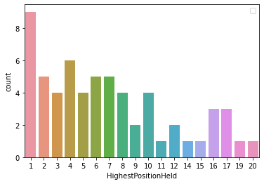

```python
# Plotting the distribution of HighestPositionHeld
sns.countplot('HighestPositionHeld',data=df1)
plt.legend()
```

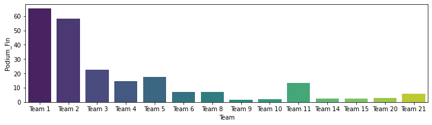

```python
# Plot of teams against Podium_Fin
plt.figure(figsize=(12,3))
df_temp=df1[df1['Podium_Fin']>0]
sns.barplot(x=df_temp['Team'],y=df_temp['Podium_Fin'],palette ='viridis')
```

Only 14 teams have ever finished as Champion or Runner-up. Teams 1 and 2 are most successful with Podium Finishes in > 50% of the Tournaments

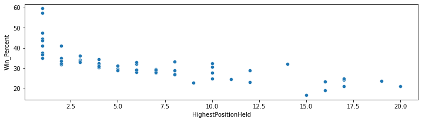

```python
# Plot of HighestPositionHeld against Win_Percent
plt.figure(figsize=(12,3))
df_temp=df1[df1['Win_Percent']>0]
sns.scatterplot(x=df_temp['HighestPositionHeld'],y=df_temp['Win_Percent'])
```

Teams with HighestPositionsHeld < 5 tend to have Win_Percent > 30%

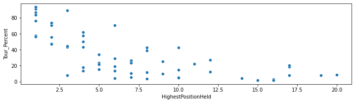

```python
plt.figure(figsize=(12,3))
#df_temp=df1[df1['Win_Percent']>0]
sns.scatterplot(x=df1['HighestPositionHeld'],y=df1['Tour_Percent'])
```

The teams that have participated regularly in tournaments ahve higher chances of improving performance and achieving better positions on the table

```python
df1.groupby(by='HighestPositionHeld').apply(display)
```

|  | Team | Tournament | Score | PlayedGames | HighestPositionHeld | YearLaunch | Age | BasketDiff | Win_Percent | Podium_Fin | SPG | Tour_Percent |
| --- | --- | --- | --- | --- | --- | --- | --- | --- | --- | --- | --- | --- |
| 0 | Team 1 | 86 | 4385 | 2762 | 1 | 1929 | 92 | 1.016293 | 59.630702 | 65.116279 | 1.587618 | 93.478261 |
| 1 | Team 2 | 86 | 4262 | 2762 | 1 | 1929 | 92 | 1.008689 | 57.241130 | 58.139535 | 1.543085 | 93.478261 |
| 2 | Team 3 | 80 | 3442 | 2614 | 1 | 1929 | 92 | 0.468630 | 47.475134 | 22.500000 | 1.316756 | 86.956522 |
| 3 | Team 4 | 82 | 3386 | 2664 | 1 | 1931 | 90 | 0.348724 | 44.557057 | 14.634146 | 1.271021 | 91.111111 |
| 4 | Team 5 | 86 | 3368 | 2762 | 1 | 1929 | 92 | 0.337075 | 43.772629 | 17.441860 | 1.219406 | 93.478261 |
| 5 | Team 6 | 73 | 2819 | 2408 | 1 | 1934 | 87 | 0.127492 | 41.112957 | 6.849315 | 1.170681 | 83.908046 |
| 7 | Team 8 | 70 | 2573 | 2302 | 1 | 1929 | 92 | -0.000869 | 37.532580 | 7.142857 | 1.117724 | 76.086957 |
| 9 | Team 10 | 51 | 1884 | 1728 | 1 | 1932 | 89 | -0.192708 | 35.069444 | 1.960784 | 1.090278 | 57.303371 |
| 10 | Team 11 | 45 | 1814 | 1530 | 1 | 1941 | 80 | -0.088889 | 36.797386 | 13.333333 | 1.185621 | 56.250000 |

|  | Team | Tournament | Score | PlayedGames | HighestPositionHeld | YearLaunch | Age | BasketDiff | Win_Percent | Podium_Fin | SPG | Tour_Percent |
| --- | --- | --- | --- | --- | --- | --- | --- | --- | --- | --- | --- | --- |
| 8 | Team 9 | 58 | 2109 | 1986 | 2 | 1939 | 82 | -0.082578 | 35.146022 | 1.724138 | 1.061934 | 70.731707 |
| 13 | Team 14 | 44 | 1416 | 1428 | 2 | 1929 | 92 | -0.367647 | 31.722689 | 2.272727 | 0.991597 | 47.826087 |
| 14 | Team 15 | 43 | 1389 | 1458 | 2 | 1944 | 77 | -0.273663 | 32.304527 | 2.325581 | 0.952675 | 55.844156 |
| 19 | Team 20 | 33 | 1020 | 1096 | 2 | 1951 | 70 | -0.364051 | 33.485401 | 3.030303 | 0.930657 | 47.142857 |
| 20 | Team 21 | 17 | 970 | 646 | 2 | 1998 | 23 | 0.159443 | 41.176471 | 5.882353 | 1.501548 | 73.913043 |

|  | Team | Tournament | Score | PlayedGames | HighestPositionHeld | YearLaunch | Age | BasketDiff | Win_Percent | Podium_Fin | SPG | Tour_Percent |
| --- | --- | --- | --- | --- | --- | --- | --- | --- | --- | --- | --- | --- |
| 6 | Team 7 | 82 | 2792 | 2626 | 3 | 1929 | 92 | -0.106626 | 36.100533 | 0.0 | 1.063214 | 89.130435 |
| 17 | Team 18 | 38 | 1174 | 1192 | 3 | 1933 | 88 | -0.259228 | 34.228188 | 0.0 | 0.984899 | 43.181818 |
| 18 | Team 19 | 27 | 1148 | 988 | 3 | 1960 | 61 | -0.191296 | 33.704453 | 0.0 | 1.161943 | 44.262295 |
| 44 | Team 45 | 7 | 107 | 130 | 3 | 1929 | 92 | -0.623077 | 33.076923 | 0.0 | 0.823077 | 7.608696 |

|  | Team | Tournament | Score | PlayedGames | HighestPositionHeld | YearLaunch | Age | BasketDiff | Win_Percent | Podium_Fin | SPG | Tour_Percent |
| --- | --- | --- | --- | --- | --- | --- | --- | --- | --- | --- | --- | --- |
| 11 | Team 12 | 51 | 1789 | 1698 | 4 | 1939 | 82 | -0.203769 | 34.511190 | 0.0 | 1.053592 | 62.195122 |
| 12 | Team 13 | 42 | 1471 | 1466 | 4 | 1948 | 73 | -0.281719 | 31.582538 | 0.0 | 1.003411 | 57.534247 |
| 15 | Team 16 | 37 | 1351 | 1318 | 4 | 1935 | 86 | -0.253414 | 32.321700 | 0.0 | 1.025038 | 43.023256 |
| 16 | Team 17 | 36 | 1314 | 1255 | 4 | 1949 | 72 | -0.272510 | 31.075697 | 0.0 | 1.047012 | 50.000000 |
| 31 | Team 32 | 14 | 353 | 426 | 4 | 1943 | 78 | -0.535211 | 30.281690 | 0.0 | 0.828638 | 17.948718 |
| 34 | Team 35 | 11 | 285 | 334 | 4 | 1941 | 80 | -0.505988 | 30.838323 | 0.0 | 0.853293 | 13.750000 |

|  | Team | Tournament | Score | PlayedGames | HighestPositionHeld | YearLaunch | Age | BasketDiff | Win_Percent | Podium_Fin | SPG | Tour_Percent |
| --- | --- | --- | --- | --- | --- | --- | --- | --- | --- | --- | --- | --- |
| 23 | Team 24 | 21 | 606 | 678 | 5 | 1959 | 62 | -0.401180 | 29.941003 | 0.0 | 0.893805 | 33.870968 |
| 25 | Team 26 | 20 | 538 | 628 | 5 | 1935 | 86 | -0.531847 | 29.299363 | 0.0 | 0.856688 | 23.255814 |
| 26 | Team 27 | 13 | 510 | 494 | 5 | 1961 | 60 | -0.253036 | 31.376518 | 0.0 | 1.032389 | 21.666667 |
| 37 | Team 38 | 9 | 230 | 282 | 5 | 1962 | 59 | -0.514184 | 29.078014 | 0.0 | 0.815603 | 15.254237 |

|  | Team | Tournament | Score | PlayedGames | HighestPositionHeld | YearLaunch | Age | BasketDiff | Win_Percent | Podium_Fin | SPG | Tour_Percent |
| --- | --- | --- | --- | --- | --- | --- | --- | --- | --- | --- | --- | --- |
| 21 | Team 22 | 23 | 667 | 742 | 6 | 1941 | 80 | -0.455526 | 29.380054 | 0.0 | 0.898922 | 28.750000 |
| 24 | Team 25 | 12 | 553 | 456 | 6 | 2004 | 17 | -0.247807 | 32.236842 | 0.0 | 1.212719 | 70.588235 |
| 28 | Team 29 | 12 | 421 | 380 | 6 | 1930 | 91 | -0.434211 | 32.894737 | 0.0 | 1.107895 | 13.186813 |
| 29 | Team 30 | 11 | 416 | 402 | 6 | 1963 | 58 | -0.502488 | 28.109453 | 0.0 | 1.034826 | 18.965517 |
| 51 | Team 52 | 4 | 56 | 72 | 6 | 1929 | 92 | -0.430556 | 29.166667 | 0.0 | 0.777778 | 4.347826 |

|  | Team | Tournament | Score | PlayedGames | HighestPositionHeld | YearLaunch | Age | BasketDiff | Win_Percent | Podium_Fin | SPG | Tour_Percent |
| --- | --- | --- | --- | --- | --- | --- | --- | --- | --- | --- | --- | --- |
| 30 | Team 31 | 12 | 375 | 423 | 7 | 1974 | 47 | -0.375887 | 29.078014 | 0.0 | 0.886525 | 25.531915 |
| 33 | Team 34 | 9 | 293 | 346 | 7 | 1987 | 34 | -0.572254 | 27.745665 | 0.0 | 0.846821 | 26.470588 |
| 35 | Team 36 | 7 | 277 | 270 | 7 | 1991 | 30 | -0.333333 | 28.148148 | 0.0 | 1.025926 | 23.333333 |
| 41 | Team 42 | 6 | 150 | 180 | 7 | 1963 | 58 | -0.311111 | 29.444444 | 0.0 | 0.833333 | 10.344828 |
| 46 | Team 47 | 4 | 91 | 116 | 7 | 1947 | 74 | -0.982759 | 29.310345 | 0.0 | 0.784483 | 5.405405 |

|  | Team | Tournament | Score | PlayedGames | HighestPositionHeld | YearLaunch | Age | BasketDiff | Win_Percent | Podium_Fin | SPG | Tour_Percent |
| --- | --- | --- | --- | --- | --- | --- | --- | --- | --- | --- | --- | --- |
| 22 | Team 23 | 17 | 662 | 652 | 8 | 1977 | 44 | -0.503067 | 28.987730 | 0.0 | 1.015337 | 38.636364 |
| 36 | Team 37 | 6 | 242 | 228 | 8 | 2007 | 14 | -0.535088 | 27.192982 | 0.0 | 1.061404 | 42.857143 |
| 39 | Team 40 | 5 | 188 | 186 | 8 | 1978 | 43 | -0.505376 | 26.881720 | 0.0 | 1.010753 | 11.627907 |
| 53 | Team 54 | 3 | 42 | 54 | 8 | 1929 | 92 | -0.629630 | 33.333333 | 0.0 | 0.777778 | 3.260870 |

|  | Team | Tournament | Score | PlayedGames | HighestPositionHeld | YearLaunch | Age | BasketDiff | Win_Percent | Podium_Fin | SPG | Tour_Percent |
| --- | --- | --- | --- | --- | --- | --- | --- | --- | --- | --- | --- | --- |
| 45 | Team 46 | 3 | 96 | 114 | 9 | 1990 | 31 | -0.333333 | 22.807018 | 0.0 | 0.842105 | 9.677419 |
| 60 | Team 61 | 1 | 0 | 0 | 9 | 2017 | 4 | NaN | NaN | 0.0 | NaN | 25.000000 |

|  | Team | Tournament | Score | PlayedGames | HighestPositionHeld | YearLaunch | Age | BasketDiff | Win_Percent | Podium_Fin | SPG | Tour_Percent |
| --- | --- | --- | --- | --- | --- | --- | --- | --- | --- | --- | --- | --- |
| 38 | Team 39 | 4 | 190 | 160 | 10 | 1994 | 27 | -0.262500 | 32.500000 | 0.0 | 1.187500 | 14.814815 |
| 43 | Team 44 | 3 | 132 | 114 | 10 | 2014 | 7 | -0.245614 | 30.701754 | 0.0 | 1.157895 | 42.857143 |
| 49 | Team 50 | 4 | 76 | 108 | 10 | 1945 | 76 | -0.990741 | 27.777778 | 0.0 | 0.703704 | 5.263158 |
| 52 | Team 53 | 2 | 52 | 68 | 10 | 1979 | 42 | -0.661765 | 25.000000 | 0.0 | 0.764706 | 4.761905 |

|  | Team | Tournament | Score | PlayedGames | HighestPositionHeld | YearLaunch | Age | BasketDiff | Win_Percent | Podium_Fin | SPG | Tour_Percent |
| --- | --- | --- | --- | --- | --- | --- | --- | --- | --- | --- | --- | --- |
| 27 | Team 28 | 18 | 445 | 586 | 11 | 1940 | 81 | -0.656997 | 24.744027 | 0.0 | 0.759386 | 22.222222 |

|  | Team | Tournament | Score | PlayedGames | HighestPositionHeld | YearLaunch | Age | BasketDiff | Win_Percent | Podium_Fin | SPG | Tour_Percent |
| --- | --- | --- | --- | --- | --- | --- | --- | --- | --- | --- | --- | --- |
| 32 | Team 33 | 12 | 343 | 448 | 12 | 1977 | 44 | -0.600446 | 23.214286 | 0.0 | 0.765625 | 27.272727 |
| 40 | Team 41 | 6 | 168 | 204 | 12 | 1971 | 50 | -0.460784 | 28.921569 | 0.0 | 0.823529 | 12.000000 |

|  | Team | Tournament | Score | PlayedGames | HighestPositionHeld | YearLaunch | Age | BasketDiff | Win_Percent | Podium_Fin | SPG | Tour_Percent |
| --- | --- | --- | --- | --- | --- | --- | --- | --- | --- | --- | --- | --- |
| 50 | Team 51 | 3 | 71 | 90 | 14 | 1953 | 68 | -0.688889 | 32.222222 | 0.0 | 0.788889 | 4.411765 |

|  | Team | Tournament | Score | PlayedGames | HighestPositionHeld | YearLaunch | Age | BasketDiff | Win_Percent | Podium_Fin | SPG | Tour_Percent |
| --- | --- | --- | --- | --- | --- | --- | --- | --- | --- | --- | --- | --- |
| 59 | Team 60 | 1 | 14 | 30 | 15 | 1955 | 66 | -1.033333 | 16.666667 | 0.0 | 0.466667 | 1.515152 |

|  | Team | Tournament | Score | PlayedGames | HighestPositionHeld | YearLaunch | Age | BasketDiff | Win_Percent | Podium_Fin | SPG | Tour_Percent |
| --- | --- | --- | --- | --- | --- | --- | --- | --- | --- | --- | --- | --- |
| 54 | Team 55 | 2 | 40 | 68 | 16 | 1950 | 71 | -1.647059 | 19.117647 | 0.0 | 0.588235 | 2.816901 |
| 57 | Team 58 | 1 | 22 | 30 | 16 | 1956 | 65 | -0.666667 | 23.333333 | 0.0 | 0.733333 | 1.538462 |
| 58 | Team 59 | 1 | 19 | 30 | 16 | 1951 | 70 | -1.133333 | 23.333333 | 0.0 | 0.633333 | 1.428571 |

|  | Team | Tournament | Score | PlayedGames | HighestPositionHeld | YearLaunch | Age | BasketDiff | Win_Percent | Podium_Fin | SPG | Tour_Percent |
| --- | --- | --- | --- | --- | --- | --- | --- | --- | --- | --- | --- | --- |
| 42 | Team 43 | 4 | 148 | 152 | 17 | 1999 | 22 | -0.644737 | 24.342105 | 0.0 | 0.973684 | 18.181818 |
| 47 | Team 48 | 2 | 83 | 80 | 17 | 1996 | 25 | -0.687500 | 25.000000 | 0.0 | 1.037500 | 8.000000 |
| 55 | Team 56 | 1 | 35 | 38 | 17 | 2016 | 5 | -0.500000 | 21.052632 | 0.0 | 0.921053 | 20.000000 |

|  | Team | Tournament | Score | PlayedGames | HighestPositionHeld | YearLaunch | Age | BasketDiff | Win_Percent | Podium_Fin | SPG | Tour_Percent |
| --- | --- | --- | --- | --- | --- | --- | --- | --- | --- | --- | --- | --- |
| 48 | Team 49 | 2 | 81 | 80 | 19 | 1995 | 26 | -0.5625 | 23.75 | 0.0 | 1.0125 | 7.692308 |

|  | Team | Tournament | Score | PlayedGames | HighestPositionHeld | YearLaunch | Age | BasketDiff | Win_Percent | Podium_Fin | SPG | Tour_Percent |
| --- | --- | --- | --- | --- | --- | --- | --- | --- | --- | --- | --- | --- |
| 56 | Team 57 | 1 | 34 | 38 | 20 | 2009 | 12 | -0.736842 | 21.052632 | 0.0 | 0.894737 | 8.333333 |

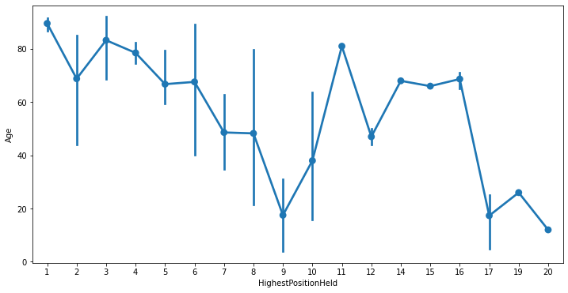

```python
plt.figure(figsize=(12,6))
sns.pointplot(x=df1['HighestPositionHeld'],y=df1['Age'],linewidth=0.25)
```

We see that on average, teams can achieve higher positions in tournaments as they play more tournaments

```python
#print out the oldest teams
df1[df1['Age']==df1['Age'].max()]
```

|  | Team | Tournament | Score | PlayedGames | HighestPositionHeld | YearLaunch | Age | BasketDiff | Win_Percent | Podium_Fin | SPG | Tour_Percent |
| --- | --- | --- | --- | --- | --- | --- | --- | --- | --- | --- | --- | --- |
| 0 | Team 1 | 86 | 4385 | 2762 | 1 | 1929 | 92 | 1.016293 | 59.630702 | 65.116279 | 1.587618 | 93.478261 |
| 1 | Team 2 | 86 | 4262 | 2762 | 1 | 1929 | 92 | 1.008689 | 57.241130 | 58.139535 | 1.543085 | 93.478261 |
| 2 | Team 3 | 80 | 3442 | 2614 | 1 | 1929 | 92 | 0.468630 | 47.475134 | 22.500000 | 1.316756 | 86.956522 |
| 4 | Team 5 | 86 | 3368 | 2762 | 1 | 1929 | 92 | 0.337075 | 43.772629 | 17.441860 | 1.219406 | 93.478261 |
| 6 | Team 7 | 82 | 2792 | 2626 | 3 | 1929 | 92 | -0.106626 | 36.100533 | 0.000000 | 1.063214 | 89.130435 |
| 7 | Team 8 | 70 | 2573 | 2302 | 1 | 1929 | 92 | -0.000869 | 37.532580 | 7.142857 | 1.117724 | 76.086957 |
| 13 | Team 14 | 44 | 1416 | 1428 | 2 | 1929 | 92 | -0.367647 | 31.722689 | 2.272727 | 0.991597 | 47.826087 |
| 44 | Team 45 | 7 | 107 | 130 | 3 | 1929 | 92 | -0.623077 | 33.076923 | 0.000000 | 0.823077 | 7.608696 |
| 51 | Team 52 | 4 | 56 | 72 | 6 | 1929 | 92 | -0.430556 | 29.166667 | 0.000000 | 0.777778 | 4.347826 |
| 53 | Team 54 | 3 | 42 | 54 | 8 | 1929 | 92 | -0.629630 | 33.333333 | 0.000000 | 0.777778 | 3.260870 |

```python
#Identifying the teams that have played most games
df1.sort_values('PlayedGames',ascending=False).head(3)
```

|  | Team | Tournament | Score | PlayedGames | HighestPositionHeld | YearLaunch | Age | BasketDiff | Win_Percent | Podium_Fin | SPG | Tour_Percent |
| --- | --- | --- | --- | --- | --- | --- | --- | --- | --- | --- | --- | --- |
| 0 | Team 1 | 86 | 4385 | 2762 | 1 | 1929 | 92 | 1.016293 | 59.630702 | 65.116279 | 1.587618 | 93.478261 |
| 1 | Team 2 | 86 | 4262 | 2762 | 1 | 1929 | 92 | 1.008689 | 57.241130 | 58.139535 | 1.543085 | 93.478261 |
| 4 | Team 5 | 86 | 3368 | 2762 | 1 | 1929 | 92 | 0.337075 | 43.772629 | 17.441860 | 1.219406 | 93.478261 |

At an overall level, let us try to identify potential candidates for recommendation to Company X. We will capture the top 3 best performing teams across multiple parameters for performance and collate the list.

```python
# Defining a set to capture Potential Investment Candidates as derived through our analysis
candidates =set()
```

```python
# Identifying Top 3 teams basis SPG
df1.sort_values('SPG',ascending=False).head(3)
```

|  | Team | Tournament | Score | PlayedGames | HighestPositionHeld | YearLaunch | Age | BasketDiff | Win_Percent | Podium_Fin | SPG | Tour_Percent |
| --- | --- | --- | --- | --- | --- | --- | --- | --- | --- | --- | --- | --- |
| 0 | Team 1 | 86 | 4385 | 2762 | 1 | 1929 | 92 | 1.016293 | 59.630702 | 65.116279 | 1.587618 | 93.478261 |
| 1 | Team 2 | 86 | 4262 | 2762 | 1 | 1929 | 92 | 1.008689 | 57.241130 | 58.139535 | 1.543085 | 93.478261 |
| 20 | Team 21 | 17 | 970 | 646 | 2 | 1998 | 23 | 0.159443 | 41.176471 | 5.882353 | 1.501548 | 73.913043 |

```python
# Add these to candidates
candidates.update(df1.sort_values('SPG',ascending=False).head(3)['Team'].unique())
candidates
```

```
{'Team 1', 'Team 2', 'Team 21'}
```

```python
# Similarly checking the lowest ranked teams by SPG
df1.sort_values('SPG',ascending=False).tail(3)
```

|  | Team | Tournament | Score | PlayedGames | HighestPositionHeld | YearLaunch | Age | BasketDiff | Win_Percent | Podium_Fin | SPG | Tour_Percent |
| --- | --- | --- | --- | --- | --- | --- | --- | --- | --- | --- | --- | --- |
| 54 | Team 55 | 2 | 40 | 68 | 16 | 1950 | 71 | -1.647059 | 19.117647 | 0.0 | 0.588235 | 2.816901 |
| 59 | Team 60 | 1 | 14 | 30 | 15 | 1955 | 66 | -1.033333 | 16.666667 | 0.0 | 0.466667 | 1.515152 |
| 60 | Team 61 | 1 | 0 | 0 | 9 | 2017 | 4 | NaN | NaN | 0.0 | NaN | 25.000000 |

Next let us identify the teams with maximum BasketDiff

```python
# Identifying Top 3 teams by greatest BasketDiff
df1.sort_values('BasketDiff',ascending=False).head(3)
```

|  | Team | Tournament | Score | PlayedGames | HighestPositionHeld | YearLaunch | Age | BasketDiff | Win_Percent | Podium_Fin | SPG | Tour_Percent |
| --- | --- | --- | --- | --- | --- | --- | --- | --- | --- | --- | --- | --- |
| 0 | Team 1 | 86 | 4385 | 2762 | 1 | 1929 | 92 | 1.016293 | 59.630702 | 65.116279 | 1.587618 | 93.478261 |
| 1 | Team 2 | 86 | 4262 | 2762 | 1 | 1929 | 92 | 1.008689 | 57.241130 | 58.139535 | 1.543085 | 93.478261 |
| 2 | Team 3 | 80 | 3442 | 2614 | 1 | 1929 | 92 | 0.468630 | 47.475134 | 22.500000 | 1.316756 | 86.956522 |

```python
candidates.update(df1.sort_values('BasketDiff',ascending=False).head(3)['Team'].unique())
# Similarly checking the lowest ranked teams by BasketDiff
df1.sort_values('BasketDiff',ascending=False).tail(3)
```

|  | Team | Tournament | Score | PlayedGames | HighestPositionHeld | YearLaunch | Age | BasketDiff | Win_Percent | Podium_Fin | SPG | Tour_Percent |
| --- | --- | --- | --- | --- | --- | --- | --- | --- | --- | --- | --- | --- |
| 58 | Team 59 | 1 | 19 | 30 | 16 | 1951 | 70 | -1.133333 | 23.333333 | 0.0 | 0.633333 | 1.428571 |
| 54 | Team 55 | 2 | 40 | 68 | 16 | 1950 | 71 | -1.647059 | 19.117647 | 0.0 | 0.588235 | 2.816901 |
| 60 | Team 61 | 1 | 0 | 0 | 9 | 2017 | 4 | NaN | NaN | 0.0 | NaN | 25.000000 |

```python
#Identifying Top 3 teams by greatest Win_Percent
df1.sort_values('Win_Percent',ascending=False).head(3)
```

|  | Team | Tournament | Score | PlayedGames | HighestPositionHeld | YearLaunch | Age | BasketDiff | Win_Percent | Podium_Fin | SPG | Tour_Percent |
| --- | --- | --- | --- | --- | --- | --- | --- | --- | --- | --- | --- | --- |
| 0 | Team 1 | 86 | 4385 | 2762 | 1 | 1929 | 92 | 1.016293 | 59.630702 | 65.116279 | 1.587618 | 93.478261 |
| 1 | Team 2 | 86 | 4262 | 2762 | 1 | 1929 | 92 | 1.008689 | 57.241130 | 58.139535 | 1.543085 | 93.478261 |
| 2 | Team 3 | 80 | 3442 | 2614 | 1 | 1929 | 92 | 0.468630 | 47.475134 | 22.500000 | 1.316756 | 86.956522 |

No new candidates here.

```python
# Similarly checking the lowest ranked teams by Win_Percent
df1.sort_values('Win_Percent',ascending=False).tail(3)
```

|  | Team | Tournament | Score | PlayedGames | HighestPositionHeld | YearLaunch | Age | BasketDiff | Win_Percent | Podium_Fin | SPG | Tour_Percent |
| --- | --- | --- | --- | --- | --- | --- | --- | --- | --- | --- | --- | --- |
| 54 | Team 55 | 2 | 40 | 68 | 16 | 1950 | 71 | -1.647059 | 19.117647 | 0.0 | 0.588235 | 2.816901 |
| 59 | Team 60 | 1 | 14 | 30 | 15 | 1955 | 66 | -1.033333 | 16.666667 | 0.0 | 0.466667 | 1.515152 |
| 60 | Team 61 | 1 | 0 | 0 | 9 | 2017 | 4 | NaN | NaN | 0.0 | NaN | 25.000000 |

```python
#Identifying Top 3 teams by greatest Podium_Fin
df1.sort_values('Podium_Fin',ascending=False).head(3)
```

|  | Team | Tournament | Score | PlayedGames | HighestPositionHeld | YearLaunch | Age | BasketDiff | Win_Percent | Podium_Fin | SPG | Tour_Percent |
| --- | --- | --- | --- | --- | --- | --- | --- | --- | --- | --- | --- | --- |
| 0 | Team 1 | 86 | 4385 | 2762 | 1 | 1929 | 92 | 1.016293 | 59.630702 | 65.116279 | 1.587618 | 93.478261 |
| 1 | Team 2 | 86 | 4262 | 2762 | 1 | 1929 | 92 | 1.008689 | 57.241130 | 58.139535 | 1.543085 | 93.478261 |
| 2 | Team 3 | 80 | 3442 | 2614 | 1 | 1929 | 92 | 0.468630 | 47.475134 | 22.500000 | 1.316756 | 86.956522 |

No new candidates identified.

```python
# Similarly checking the lowest ranked teams by Podium_Fin
df1.sort_values('Podium_Fin',ascending=False).tail(3)
```

|  | Team | Tournament | Score | PlayedGames | HighestPositionHeld | YearLaunch | Age | BasketDiff | Win_Percent | Podium_Fin | SPG | Tour_Percent |
| --- | --- | --- | --- | --- | --- | --- | --- | --- | --- | --- | --- | --- |
| 33 | Team 34 | 9 | 293 | 346 | 7 | 1987 | 34 | -0.572254 | 27.745665 | 0.0 | 0.846821 | 26.470588 |
| 34 | Team 35 | 11 | 285 | 334 | 4 | 1941 | 80 | -0.505988 | 30.838323 | 0.0 | 0.853293 | 13.750000 |
| 60 | Team 61 | 1 | 0 | 0 | 9 | 2017 | 4 | NaN | NaN | 0.0 | NaN | 25.000000 |

```python
# Who are our candidates now?
candidates
```

```
{'Team 1', 'Team 2', 'Team 21', 'Team 3'}
```

Next, let us look at the prevailing correlations between the data and see if any parameter correlates to Podium_Fin or TournamentChampion or Highest Position

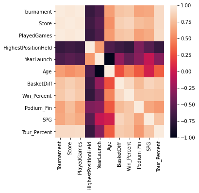

```python
plt.figure(figsize=(5,5))
sns.heatmap(df1.corr())
```

```python
# Creating a temporary dataframe for easier plotting
df1_temp=df1[['Team','Tournament','SPG','PlayedGames',"BasketDiff",
              'Age','Win_Percent','Podium_Fin','HighestPositionHeld','Tour_Percent']]
```

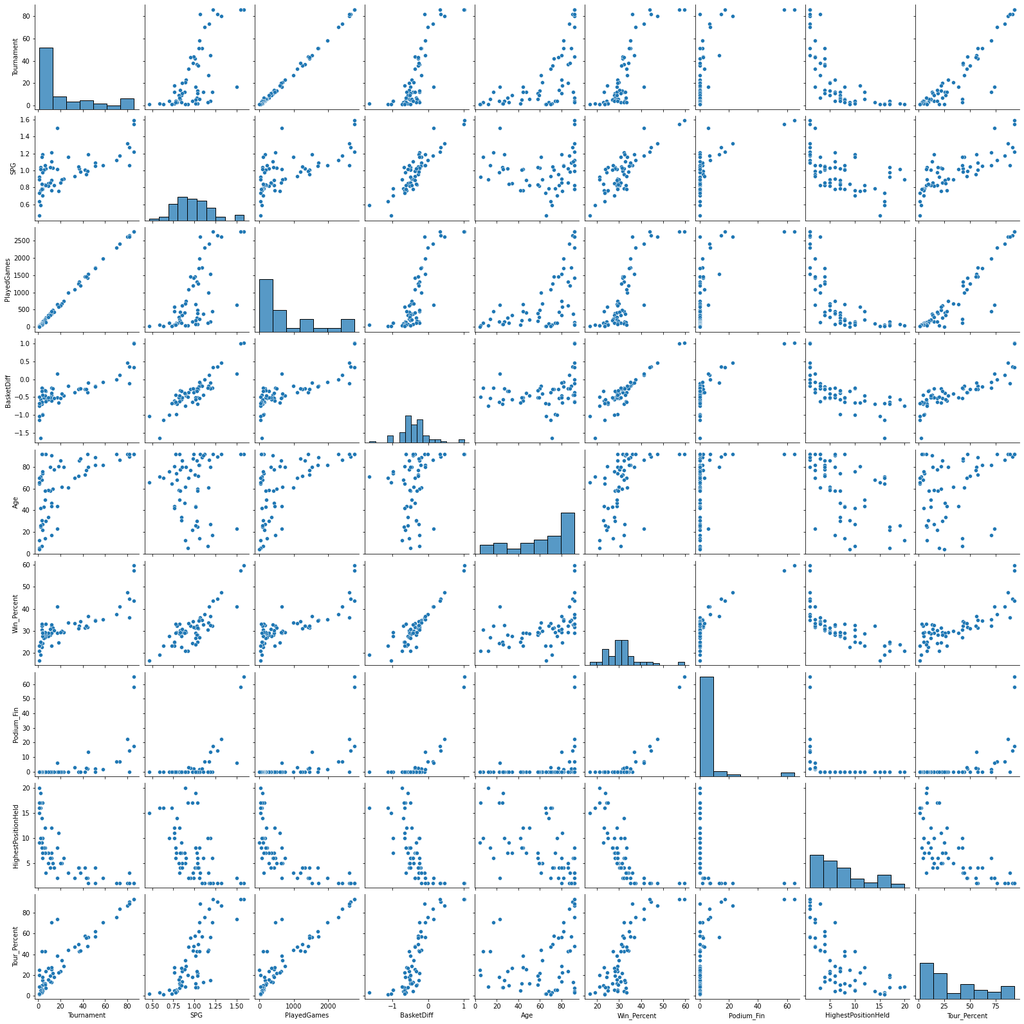

```python
sns.pairplot(df1_temp)
```

We note the following from the correlation heat-map and the pair-plots:

Hence, for our recommendation process flow, we note that:

- Characteristics are distinct for older and newer teams. Newer teams take time to achieve high positions on the table. Hence, our approach should be different for older teams and emerging teams
- Also, we see that chances of success increase with more games. We should track teams who play regularly in the tournament. Hence, we should establish a cut-off on the Tour_Percent as well.

[output not shown]

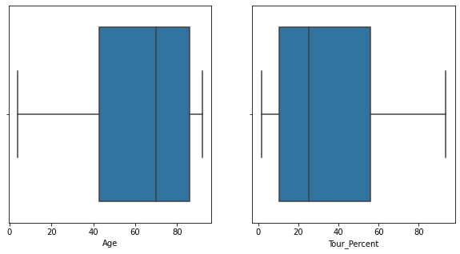

```python
#Checking the box plot for Age & PlayedGames
fig,ax = plt.subplots(1,2)

fig.set_figheight(5)
fig.set_figwidth(10)

sns.boxplot(df1['Age'],ax=ax[0])
sns.boxplot(df1['Tour_Percent'],ax=ax[1])
```

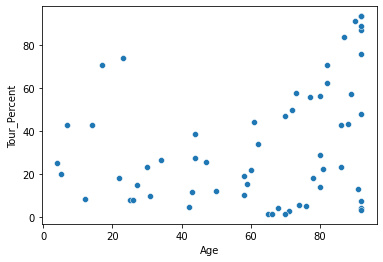

```python
sns.scatterplot(x=df1['Age'],y=df1['Tour_Percent'])
```

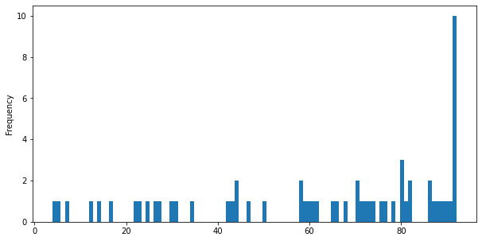

```python
#plotting a distribution of Team Age
plt.figure(figsize=(10,5))
df1['Age'].plot.hist(bins=100)
```

With this we will create a subset of our dataset and proceed with further analysis

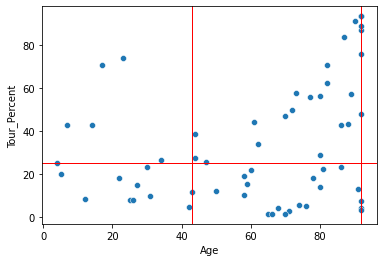

```python
sns.scatterplot(x=df1['Age'],y=df1['Tour_Percent'])
plt.axhline(25,linewidth = 1, color='red') #Tour_Percent cut-off
plt.axvline(92,linewidth=1,color='red') #Age upper cut-off
plt.axvline(43,linewidth=1,color='red') #Age lower cut-off
```

```python
# Creating a subset of our dataset
#df2= df1[(df1['YearLaunch'] >1929)& (df1['YearLaunch']<1981) ]
df2 = df1[(df1['Age']<92) & (df1['Age']>43) & (df1['Tour_Percent']> 25) & (df1['HighestPositionHeld']<6)]
df2
```

|  | Team | Tournament | Score | PlayedGames | HighestPositionHeld | YearLaunch | Age | BasketDiff | Win_Percent | Podium_Fin | SPG | Tour_Percent |
| --- | --- | --- | --- | --- | --- | --- | --- | --- | --- | --- | --- | --- |
| 3 | Team 4 | 82 | 3386 | 2664 | 1 | 1931 | 90 | 0.348724 | 44.557057 | 14.634146 | 1.271021 | 91.111111 |
| 5 | Team 6 | 73 | 2819 | 2408 | 1 | 1934 | 87 | 0.127492 | 41.112957 | 6.849315 | 1.170681 | 83.908046 |
| 8 | Team 9 | 58 | 2109 | 1986 | 2 | 1939 | 82 | -0.082578 | 35.146022 | 1.724138 | 1.061934 | 70.731707 |
| 9 | Team 10 | 51 | 1884 | 1728 | 1 | 1932 | 89 | -0.192708 | 35.069444 | 1.960784 | 1.090278 | 57.303371 |
| 10 | Team 11 | 45 | 1814 | 1530 | 1 | 1941 | 80 | -0.088889 | 36.797386 | 13.333333 | 1.185621 | 56.250000 |
| 11 | Team 12 | 51 | 1789 | 1698 | 4 | 1939 | 82 | -0.203769 | 34.511190 | 0.000000 | 1.053592 | 62.195122 |
| 12 | Team 13 | 42 | 1471 | 1466 | 4 | 1948 | 73 | -0.281719 | 31.582538 | 0.000000 | 1.003411 | 57.534247 |
| 14 | Team 15 | 43 | 1389 | 1458 | 2 | 1944 | 77 | -0.273663 | 32.304527 | 2.325581 | 0.952675 | 55.844156 |
| 15 | Team 16 | 37 | 1351 | 1318 | 4 | 1935 | 86 | -0.253414 | 32.321700 | 0.000000 | 1.025038 | 43.023256 |
| 16 | Team 17 | 36 | 1314 | 1255 | 4 | 1949 | 72 | -0.272510 | 31.075697 | 0.000000 | 1.047012 | 50.000000 |
| 17 | Team 18 | 38 | 1174 | 1192 | 3 | 1933 | 88 | -0.259228 | 34.228188 | 0.000000 | 0.984899 | 43.181818 |
| 18 | Team 19 | 27 | 1148 | 988 | 3 | 1960 | 61 | -0.191296 | 33.704453 | 0.000000 | 1.161943 | 44.262295 |
| 19 | Team 20 | 33 | 1020 | 1096 | 2 | 1951 | 70 | -0.364051 | 33.485401 | 3.030303 | 0.930657 | 47.142857 |
| 23 | Team 24 | 21 | 606 | 678 | 5 | 1959 | 62 | -0.401180 | 29.941003 | 0.000000 | 0.893805 | 33.870968 |

**For Emerging Teams:** For teams aged < 43, let us check if we missed any potential teams that have played tournaments regularly and secured top 10 atleast once (we can be linient on HighestPostionHeld since we know that younger teams take time to establish themselves

With this we will create a subset of our dataset and proceed with further analysis

```python
#Age cut-off
df1[(df1['Age']<=43) & (df1['Tour_Percent']>25) & (df1['HighestPositionHeld']<=10)]
```

|  | Team | Tournament | Score | PlayedGames | HighestPositionHeld | YearLaunch | Age | BasketDiff | Win_Percent | Podium_Fin | SPG | Tour_Percent |
| --- | --- | --- | --- | --- | --- | --- | --- | --- | --- | --- | --- | --- |
| 20 | Team 21 | 17 | 970 | 646 | 2 | 1998 | 23 | 0.159443 | 41.176471 | 5.882353 | 1.501548 | 73.913043 |
| 24 | Team 25 | 12 | 553 | 456 | 6 | 2004 | 17 | -0.247807 | 32.236842 | 0.000000 | 1.212719 | 70.588235 |
| 33 | Team 34 | 9 | 293 | 346 | 7 | 1987 | 34 | -0.572254 | 27.745665 | 0.000000 | 0.846821 | 26.470588 |
| 36 | Team 37 | 6 | 242 | 228 | 8 | 2007 | 14 | -0.535088 | 27.192982 | 0.000000 | 1.061404 | 42.857143 |
| 43 | Team 44 | 3 | 132 | 114 | 10 | 2014 | 7 | -0.245614 | 30.701754 | 0.000000 | 1.157895 | 42.857143 |

We see that these teams have good participation rates since their launch along with high SPG and is a potential candidate since it has BasketDiff >0, Win_Percent >30% and Podium_Fin >0. Since there are only 5, instead of performing separate analysis, we can include them with our dataframe for older-teams for analysis. Let us include these in our dataframe

```python
#Emerging teams into dataset
df2=df2.append(df1[(df1['Age']<=43) & (df1['Tour_Percent']>25) & (df1['HighestPositionHeld']<=10)]).sort_index()
df2
```

|  | Team | Tournament | Score | PlayedGames | HighestPositionHeld | YearLaunch | Age | BasketDiff | Win_Percent | Podium_Fin | SPG | Tour_Percent |
| --- | --- | --- | --- | --- | --- | --- | --- | --- | --- | --- | --- | --- |
| 3 | Team 4 | 82 | 3386 | 2664 | 1 | 1931 | 90 | 0.348724 | 44.557057 | 14.634146 | 1.271021 | 91.111111 |
| 5 | Team 6 | 73 | 2819 | 2408 | 1 | 1934 | 87 | 0.127492 | 41.112957 | 6.849315 | 1.170681 | 83.908046 |
| 8 | Team 9 | 58 | 2109 | 1986 | 2 | 1939 | 82 | -0.082578 | 35.146022 | 1.724138 | 1.061934 | 70.731707 |
| 9 | Team 10 | 51 | 1884 | 1728 | 1 | 1932 | 89 | -0.192708 | 35.069444 | 1.960784 | 1.090278 | 57.303371 |
| 10 | Team 11 | 45 | 1814 | 1530 | 1 | 1941 | 80 | -0.088889 | 36.797386 | 13.333333 | 1.185621 | 56.250000 |
| 11 | Team 12 | 51 | 1789 | 1698 | 4 | 1939 | 82 | -0.203769 | 34.511190 | 0.000000 | 1.053592 | 62.195122 |
| 12 | Team 13 | 42 | 1471 | 1466 | 4 | 1948 | 73 | -0.281719 | 31.582538 | 0.000000 | 1.003411 | 57.534247 |
| 14 | Team 15 | 43 | 1389 | 1458 | 2 | 1944 | 77 | -0.273663 | 32.304527 | 2.325581 | 0.952675 | 55.844156 |
| 15 | Team 16 | 37 | 1351 | 1318 | 4 | 1935 | 86 | -0.253414 | 32.321700 | 0.000000 | 1.025038 | 43.023256 |
| 16 | Team 17 | 36 | 1314 | 1255 | 4 | 1949 | 72 | -0.272510 | 31.075697 | 0.000000 | 1.047012 | 50.000000 |
| 17 | Team 18 | 38 | 1174 | 1192 | 3 | 1933 | 88 | -0.259228 | 34.228188 | 0.000000 | 0.984899 | 43.181818 |
| 18 | Team 19 | 27 | 1148 | 988 | 3 | 1960 | 61 | -0.191296 | 33.704453 | 0.000000 | 1.161943 | 44.262295 |
| 19 | Team 20 | 33 | 1020 | 1096 | 2 | 1951 | 70 | -0.364051 | 33.485401 | 3.030303 | 0.930657 | 47.142857 |
| 20 | Team 21 | 17 | 970 | 646 | 2 | 1998 | 23 | 0.159443 | 41.176471 | 5.882353 | 1.501548 | 73.913043 |
| 23 | Team 24 | 21 | 606 | 678 | 5 | 1959 | 62 | -0.401180 | 29.941003 | 0.000000 | 0.893805 | 33.870968 |
| 24 | Team 25 | 12 | 553 | 456 | 6 | 2004 | 17 | -0.247807 | 32.236842 | 0.000000 | 1.212719 | 70.588235 |
| 33 | Team 34 | 9 | 293 | 346 | 7 | 1987 | 34 | -0.572254 | 27.745665 | 0.000000 | 0.846821 | 26.470588 |
| 36 | Team 37 | 6 | 242 | 228 | 8 | 2007 | 14 | -0.535088 | 27.192982 | 0.000000 | 1.061404 | 42.857143 |
| 43 | Team 44 | 3 | 132 | 114 | 10 | 2014 | 7 | -0.245614 | 30.701754 | 0.000000 | 1.157895 | 42.857143 |

### Candidate Selection

Let us go back to our candidates list and see if they pass the criteria set above

```python
# Check if candidates identified earlier meet the criteria
df2[df2['Team'].isin(candidates)]
```

|  | Team | Tournament | Score | PlayedGames | HighestPositionHeld | YearLaunch | Age | BasketDiff | Win_Percent | Podium_Fin | SPG | Tour_Percent |
| --- | --- | --- | --- | --- | --- | --- | --- | --- | --- | --- | --- | --- |
| 20 | Team 21 | 17 | 970 | 646 | 2 | 1998 | 23 | 0.159443 | 41.176471 | 5.882353 | 1.501548 | 73.913043 |

Only Team 21 meet the criteria. We can retain it and remove the rest. Then we will adopt the same process we followed earlier to identify candidates

```python
candidates=set(df2[df2['Team'].isin(candidates)]['Team'].values)
```

```python
# Identifying top 3 teams by SPG & updating candidates
df2.sort_values(by='SPG',ascending=False).head(3)
```

|  | Team | Tournament | Score | PlayedGames | HighestPositionHeld | YearLaunch | Age | BasketDiff | Win_Percent | Podium_Fin | SPG | Tour_Percent |
| --- | --- | --- | --- | --- | --- | --- | --- | --- | --- | --- | --- | --- |
| 20 | Team 21 | 17 | 970 | 646 | 2 | 1998 | 23 | 0.159443 | 41.176471 | 5.882353 | 1.501548 | 73.913043 |
| 3 | Team 4 | 82 | 3386 | 2664 | 1 | 1931 | 90 | 0.348724 | 44.557057 | 14.634146 | 1.271021 | 91.111111 |
| 24 | Team 25 | 12 | 553 | 456 | 6 | 2004 | 17 | -0.247807 | 32.236842 | 0.000000 | 1.212719 | 70.588235 |

```python
candidates.update(df2.sort_values(by='SPG',ascending=False).head(3)['Team'])
```

```python
#Identifying highest Win_Percent, BasketDiff & Podium_Fin teams & updating candidates
```

```python
df2.sort_values(by='Win_Percent',ascending=False).head(3)
```

|  | Team | Tournament | Score | PlayedGames | HighestPositionHeld | YearLaunch | Age | BasketDiff | Win_Percent | Podium_Fin | SPG | Tour_Percent |
| --- | --- | --- | --- | --- | --- | --- | --- | --- | --- | --- | --- | --- |
| 3 | Team 4 | 82 | 3386 | 2664 | 1 | 1931 | 90 | 0.348724 | 44.557057 | 14.634146 | 1.271021 | 91.111111 |
| 20 | Team 21 | 17 | 970 | 646 | 2 | 1998 | 23 | 0.159443 | 41.176471 | 5.882353 | 1.501548 | 73.913043 |
| 5 | Team 6 | 73 | 2819 | 2408 | 1 | 1934 | 87 | 0.127492 | 41.112957 | 6.849315 | 1.170681 | 83.908046 |

```python
candidates.update(df2.sort_values(by='Win_Percent',ascending=False).head(3)['Team'])
```

```python
df2.sort_values(by='BasketDiff',ascending=False).head(3)
```

|  | Team | Tournament | Score | PlayedGames | HighestPositionHeld | YearLaunch | Age | BasketDiff | Win_Percent | Podium_Fin | SPG | Tour_Percent |
| --- | --- | --- | --- | --- | --- | --- | --- | --- | --- | --- | --- | --- |
| 3 | Team 4 | 82 | 3386 | 2664 | 1 | 1931 | 90 | 0.348724 | 44.557057 | 14.634146 | 1.271021 | 91.111111 |
| 20 | Team 21 | 17 | 970 | 646 | 2 | 1998 | 23 | 0.159443 | 41.176471 | 5.882353 | 1.501548 | 73.913043 |
| 5 | Team 6 | 73 | 2819 | 2408 | 1 | 1934 | 87 | 0.127492 | 41.112957 | 6.849315 | 1.170681 | 83.908046 |

```python
candidates.update(df2.sort_values(by='BasketDiff',ascending=False).head(3)['Team'])
```

```python
df2.sort_values(by='Podium_Fin',ascending=False).head(3)
```

|  | Team | Tournament | Score | PlayedGames | HighestPositionHeld | YearLaunch | Age | BasketDiff | Win_Percent | Podium_Fin | SPG | Tour_Percent |
| --- | --- | --- | --- | --- | --- | --- | --- | --- | --- | --- | --- | --- |
| 3 | Team 4 | 82 | 3386 | 2664 | 1 | 1931 | 90 | 0.348724 | 44.557057 | 14.634146 | 1.271021 | 91.111111 |
| 10 | Team 11 | 45 | 1814 | 1530 | 1 | 1941 | 80 | -0.088889 | 36.797386 | 13.333333 | 1.185621 | 56.250000 |
| 5 | Team 6 | 73 | 2819 | 2408 | 1 | 1934 | 87 | 0.127492 | 41.112957 | 6.849315 | 1.170681 | 83.908046 |

```python
candidates.update(df2.sort_values(by='Podium_Fin',ascending=False).head(3)['Team'])
```

```python
#Identifying lowest Win_Percent, BasketDiff, Podium_Fin & SPG teams & updating candidates
df2.sort_values(by='Win_Percent',ascending=False).tail(3)
```

|  | Team | Tournament | Score | PlayedGames | HighestPositionHeld | YearLaunch | Age | BasketDiff | Win_Percent | Podium_Fin | SPG | Tour_Percent |
| --- | --- | --- | --- | --- | --- | --- | --- | --- | --- | --- | --- | --- |
| 23 | Team 24 | 21 | 606 | 678 | 5 | 1959 | 62 | -0.401180 | 29.941003 | 0.0 | 0.893805 | 33.870968 |
| 33 | Team 34 | 9 | 293 | 346 | 7 | 1987 | 34 | -0.572254 | 27.745665 | 0.0 | 0.846821 | 26.470588 |
| 36 | Team 37 | 6 | 242 | 228 | 8 | 2007 | 14 | -0.535088 | 27.192982 | 0.0 | 1.061404 | 42.857143 |

```python
df2.sort_values(by='BasketDiff',ascending=False).tail(3)
```

|  | Team | Tournament | Score | PlayedGames | HighestPositionHeld | YearLaunch | Age | BasketDiff | Win_Percent | Podium_Fin | SPG | Tour_Percent |
| --- | --- | --- | --- | --- | --- | --- | --- | --- | --- | --- | --- | --- |
| 23 | Team 24 | 21 | 606 | 678 | 5 | 1959 | 62 | -0.401180 | 29.941003 | 0.0 | 0.893805 | 33.870968 |
| 36 | Team 37 | 6 | 242 | 228 | 8 | 2007 | 14 | -0.535088 | 27.192982 | 0.0 | 1.061404 | 42.857143 |
| 33 | Team 34 | 9 | 293 | 346 | 7 | 1987 | 34 | -0.572254 | 27.745665 | 0.0 | 0.846821 | 26.470588 |

```python
df2.sort_values(by='Podium_Fin',ascending=False).tail(3)
```

|  | Team | Tournament | Score | PlayedGames | HighestPositionHeld | YearLaunch | Age | BasketDiff | Win_Percent | Podium_Fin | SPG | Tour_Percent |
| --- | --- | --- | --- | --- | --- | --- | --- | --- | --- | --- | --- | --- |
| 12 | Team 13 | 42 | 1471 | 1466 | 4 | 1948 | 73 | -0.281719 | 31.582538 | 0.0 | 1.003411 | 57.534247 |
| 11 | Team 12 | 51 | 1789 | 1698 | 4 | 1939 | 82 | -0.203769 | 34.511190 | 0.0 | 1.053592 | 62.195122 |
| 43 | Team 44 | 3 | 132 | 114 | 10 | 2014 | 7 | -0.245614 | 30.701754 | 0.0 | 1.157895 | 42.857143 |

```python
df2.sort_values(by='SPG',ascending=False).tail(3)
```

|  | Team | Tournament | Score | PlayedGames | HighestPositionHeld | YearLaunch | Age | BasketDiff | Win_Percent | Podium_Fin | SPG | Tour_Percent |
| --- | --- | --- | --- | --- | --- | --- | --- | --- | --- | --- | --- | --- |
| 19 | Team 20 | 33 | 1020 | 1096 | 2 | 1951 | 70 | -0.364051 | 33.485401 | 3.030303 | 0.930657 | 47.142857 |
| 23 | Team 24 | 21 | 606 | 678 | 5 | 1959 | 62 | -0.401180 | 29.941003 | 0.000000 | 0.893805 | 33.870968 |
| 33 | Team 34 | 9 | 293 | 346 | 7 | 1987 | 34 | -0.572254 | 27.745665 | 0.000000 | 0.846821 | 26.470588 |

```python
# Who are the candidaes at the moment?
candidates
```

```
{'Team 11', 'Team 21', 'Team 25', 'Team 4', 'Team 6'}
```

Let us look at the data once again for our candidate teams

```python
df2_temp=df2[df2['Team'].isin(candidates)]
df2_temp
```

|  | Team | Tournament | Score | PlayedGames | HighestPositionHeld | YearLaunch | Age | BasketDiff | Win_Percent | Podium_Fin | SPG | Tour_Percent |
| --- | --- | --- | --- | --- | --- | --- | --- | --- | --- | --- | --- | --- |
| 3 | Team 4 | 82 | 3386 | 2664 | 1 | 1931 | 90 | 0.348724 | 44.557057 | 14.634146 | 1.271021 | 91.111111 |
| 5 | Team 6 | 73 | 2819 | 2408 | 1 | 1934 | 87 | 0.127492 | 41.112957 | 6.849315 | 1.170681 | 83.908046 |
| 10 | Team 11 | 45 | 1814 | 1530 | 1 | 1941 | 80 | -0.088889 | 36.797386 | 13.333333 | 1.185621 | 56.250000 |
| 20 | Team 21 | 17 | 970 | 646 | 2 | 1998 | 23 | 0.159443 | 41.176471 | 5.882353 | 1.501548 | 73.913043 |
| 24 | Team 25 | 12 | 553 | 456 | 6 | 2004 | 17 | -0.247807 | 32.236842 | 0.000000 | 1.212719 | 70.588235 |

We have 5 shortlisted candidates. These teams satisfy our observations from the pair plot. All have Win_Percent >30. All have SPG > 1.0. All have Podium_Fin > 0 except Team 25 which is an emerging team. BasketDiff > 0 for all except two teams.

```python
#candidates.difference_update(df2_temp[df2_temp['Age'] > 43].sort_values(by='Podium_Fin').head(2)['Team'].values)
print( "Final candidates", candidates)
```

```
Final candidates {'Team 4', 'Team 25', 'Team 21', 'Team 11', 'Team 6'}
```

### Observations on the datapoints collected to perform a better data analysis

**Quality**:

- Pre-processed data will help save time for analysis (such as launch year without combinations, the derived attributes used in the calculation, using the right data type for storage)
- Additional data points such as Team Budgets, Head to Head records, individual match data for tournaments, Fan base, Time Since Last Appearance in tournament are useful attributes that can be captured
- Tournament level data such as the position attained in each tournament in chornological sequence will help with accounting for recent form

**Quantity**:

- For any metric there are only 61 data points available, if we take a cut on any attribute, then there are very few datapoints left to do any significance analysis/
- The data could be made richer by adding individual match data from each of the tournaments

**Variety**:

- Data from a variety of sources such as P&L statements, could be tracked to update our database
- Specifically data on Social Media fan following, Budget, etc could help assess the customer reach and RoI that Company X can target
- Data from specialist Basketball analytics companies such as Opta could be incorporated into this to add more attributes for anlysis

**Velocity**:

- The data could be updated for each match within a tournament to provide more data points for analysis.
- If we collect data frequently, we will also know updated information on the Operating Status of the teams, if any have stopped operations

**Veracity**:

- For a Basketball dataset, there are very high number of drawn games. This questions the authenticity of the data
- For Team 23, the PlayedGames does not equal the sum of games won, drawn and lost. This again, makes us doubt the veracity of the data

**Value:**

- If we are able to implement the above successfully, we can then add value by being able to predict which teams among the candidates is best by comparing Head to Head performances and recent trends
- We will be able to predict energing teams better if we have the information on trends and years since last appearance in the tournament.

## Part 3: Project Based

**Domain:** Startup Ecosystem

**Context:** Company X is a EU online publisher focusing on the startups industry. The company specifically reports on the business related to technology news, analysis of emerging trends and profiling of new tech businesses and products. Their event i.e. Startup Battlefield is the world’s pre-eminent startup competition. Startup Battlefield features 15-30 top early stage startups pitching top judges in front of a vast live audience, present in person and online.

**Data Description:** CompanyX_EU.csv - Each row in the dataset is a Start-up company and the columns describe the company.

**Attribute Information:**

1. **Startup:** Name of the company
2. **Product:** Actual product
3. **Funding:** Funds raised by the company in USD
4. **Event:** The event the company participated in
5. **Result:** Described by Contestant, Finalist, Audience choice, Winner or Runner up
6. **OperatingState:** Current status of the company, Operating ,Closed, Acquired or IPO

**Project Objective:** Analyse the data of the various companies from the given dataset and perform the tasks that are specified in the below steps. Draw insights from the various attributes that are present in the dataset, plot distributions, state hypotheses and draw conclusions from the dataset.

### Data Warehouse

```python
# read the csv file and check the top entries
startup = pd.read_csv("DS - Part3 - CompanyX_EU.csv")
```

### Data Exploration

```python
startup.head(5)
```

|  | Startup | Product | Funding | Event | Result | OperatingState |
| --- | --- | --- | --- | --- | --- | --- |
| 0 | 2600Hz | 2600hz.com | NaN | Disrupt SF 2013 | Contestant | Operating |
| 1 | 3DLT | 3dlt.com | $630K | Disrupt NYC 2013 | Contestant | Closed |
| 2 | 3DPrinterOS | 3dprinteros.com | NaN | Disrupt SF 2016 | Contestant | Operating |
| 3 | 3Dprintler | 3dprintler.com | $1M | Disrupt NY 2016 | Audience choice | Operating |
| 4 | 42 Technologies | 42technologies.com | NaN | Disrupt NYC 2013 | Contestant | Operating |

```python
# check the number of entries in dataset
startup.shape
```

```
(662, 6)
```

```python
# Data type of each attribute
startup.dtypes
```

```
Startup           object
Product           object
Funding           object
Event             object
Result            object
OperatingState    object
dtype: object
```

All the attributes are of object datatypes. We will need to convert the Funding attribute to numeric value

```python
# Checking for missing values
startup.isna().sum()
```

```
Startup             0
Product             6
Funding           214
Event               0
Result              0
OperatingState      0
dtype: int64
```

There are 6 entries missing under Product attribute and 214 entries missing under Funding

### Data Preprocessing & Visualization

```python
# Dropping the rows which have no data
startup1 = startup.dropna().copy(deep=True)
startup1.shape
```

```
(446, 6)
```

The entries in the Funding attribute are of 3 types - a) in \$M b) in \\$K c) in \$B. We need to convert these to a standard scale in \\$M with only numeric value stored in the column

```python
startup1['Funds_in_million'] = startup1['Funding'].apply(lambda x: float(x[1:-1])/1000 if x[-1] == 'K' else (float(x[1:-1])*1000 if x[-1] == 'B' else float(x[1:-1])))
```

```python
startup1.head(5)
```

|  | Startup | Product | Funding | Event | Result | OperatingState | Funds_in_million |
| --- | --- | --- | --- | --- | --- | --- | --- |
| 1 | 3DLT | 3dlt.com | $630K | Disrupt NYC 2013 | Contestant | Closed | 0.63 |
| 3 | 3Dprintler | 3dprintler.com | $1M | Disrupt NY 2016 | Audience choice | Operating | 1.00 |
| 5 | 5to1 | 5to1.com | $19.3M | TC50 2009 | Contestant | Acquired | 19.30 |
| 6 | 8 Securities | 8securities.com | $29M | Disrupt Beijing 2011 | Finalist | Operating | 29.00 |
| 10 | AdhereTech | adheretech.com | $1.8M | Hardware Battlefield 2014 | Contestant | Operating | 1.80 |

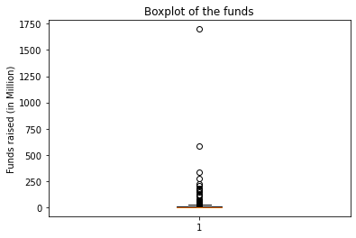

```python
# Boxplot for Funds in Mn
#sns.set_theme(style ="whitegrid")
#plt.figure(figsize=(12,6))
#sns.boxplot(x=startup1['Funds_in_million'],palette="Oranges")
plot = plt.boxplot(startup1.Funds_in_million)
plt.title('Boxplot of the funds')
plt.ylabel("Funds raised (in Million)")

plt.show()
```

The Lower Fence here is \$0.005M. We can also obtain it through the below:

```python
lower_fence = plot['caps'][0].get_data()[1][1]   # we can use the values from the box plot itself to get the lower fence
lower_fence
```

```
0.005
```

```python
upper_fence = plot['caps'][1].get_data()[1][1]   # we can use the values from the box plot itself to get the Upper fence
upper_fence
```

```
22.0
```

```python
# Finding the number of outliers beyond the upper fence
print(f'Number of outliers = {len(startup1[startup1.Funds_in_million > upper_fence])}')
```

```
Number of outliers = 60
```

```python
# Detais of companies that are outliers on Funds_in_million
startup1[startup1.Funds_in_million > upper_fence]
```

|  | Startup | Product | Funding | Event | Result | OperatingState | Funds_in_million |
| --- | --- | --- | --- | --- | --- | --- | --- |
| 6 | 8 Securities | 8securities.com | $29M | Disrupt Beijing 2011 | Finalist | Operating | 29.0 |
| 31 | Anyclip | anyclip.com | $24M | TC50 2009 | Finalist | Operating | 24.0 |
| 40 | Artsy | artsy.net | $50.9M | Disrupt NYC 2010 | Contestant | Operating | 50.9 |
| 49 | Badgeville | badgeville.com | $40M | Disrupt SF 2010 | Finalist | Acquired | 40.0 |
| 56 | Betterment | betterment.com | $205M | Disrupt NYC 2010 | Finalist | Operating | 205.0 |
| 108 | Clickable | clickable.com | $32.5M | TC40 2007 | Finalist | Acquired | 32.5 |
| 113 | Cloudflare | cloudflare.com | $182.1M | Disrupt SF 2010 | Runner up | Operating | 182.1 |
| 128 | Credit Sesame | creditsesame.com | $35.4M | Disrupt SF 2010 | Contestant | Operating | 35.4 |
| 130 | CrowdFlower Inc. | crowdflower.com | $38M | TC50 2009 | Contestant | Operating | 38.0 |
| 132 | Cubic Telecom | cubictelecom.com | $37.1M | TC40 2007 | Contestant | Operating | 37.1 |
| 138 | DataSift | datasift.com | $72M | Disrupt SF 2010 | Finalist | Operating | 72.0 |
| 139 | DataXu | dataxu.com | $64M | TC50 2009 | Contestant | Operating | 64.0 |
| 154 | Dropbox | dropbox.com | $1.7B | TC50 2008 | Contestant | Operating | 1700.0 |
| 166 | Enigma | enigma.io | $34.6M | Disrupt NYC 2013 | Winner | Operating | 34.6 |
| 172 | EverythingMe | everything.me | $35.5M | Disrupt NYC 2011 | Contestant | Closed | 35.5 |
| 179 | Famo.us | famo.us | $30.1M | Disrupt SF 2012 | Contestant | Operating | 30.1 |
| 180 | Farmigo | farmigo.com | $26M | Disrupt SF 2011 | Finalist | Operating | 26.0 |
| 188 | Fitbit | fitbit.com | $66M | TC50 2008 | Finalist | Ipo | 66.0 |
| 191 | Flock | flock.com | $28.3M | TC40 2007 | Contestant | Acquired | 28.3 |
| 209 | Getaround | getaround.com | $103M | Disrupt NYC 2011 | Winner | Operating | 103.0 |
| 213 | Gild | gild.com | $25.9M | Disrupt SF 2010 | Contestant | Acquired | 25.9 |
| 215 | Glide | glide.me | $36.5M | Disrupt NYC 2013 | Audience choice | Operating | 36.5 |
| 225 | Grockit | grockit.com | $44.7M | TC50 2008 | Finalist | Acquired | 44.7 |
| 231 | HackerRank | hackerrank.com | $24.2M | Disrupt SF 2012 | Contestant | Operating | 24.2 |
| 271 | Ionic Security | ionicsecurity.com | $122.4M | Disrupt SF 2012 | Contestant | Operating | 122.4 |
| 276 | IZEA | izea.com | $34.9M | Disrupt NYC 2010 | Contestant | Ipo | 34.9 |
| 279 | Jiff | jiff.com | $67.8M | Disrupt SF 2011 | Contestant | Acquired | 67.8 |
| 282 | Kaltura | kaltura.com | $166.1M | TC40 2007 | Audience choice | Operating | 166.1 |
| 302 | Layer | layer.com | $42.1M | Disrupt SF 2013 | Winner | Operating | 42.1 |
| 305 | LearnVest | learnvest.com | $69M | TC50 2009 | Contestant | Acquired | 69.0 |
| 313 | LiveIntent | liveintent.com | $65.1M | Disrupt NYC 2010 | Audience choice | Operating | 65.1 |
| 325 | Lystable | lystable.com | $25.1M | Disrupt London 2015 | Finalist | Operating | 25.1 |
| 346 | Mint | mint.com | $31.8M | TC40 2007 | Winner | Acquired | 31.8 |
| 389 | OrderWithMe | orderwithme.com | $37M | Disrupt Beijing 2011 | Winner | Operating | 37.0 |
| 393 | Osmo | playosmo.com | $38.5M | Disrupt SF 2013 | Contestant | Operating | 38.5 |
| 394 | Ossia | ossia.com | $25.5M | Disrupt SF 2013 | Runner up | Operating | 25.5 |
| 398 | Owlet Baby Care | owletcare.com | $24M | Hardware Battlefield 2014 | Runner up | Operating | 24.0 |
| 427 | Postmates | postmates.com | $278M | Disrupt SF 2011 | Contestant | Operating | 278.0 |
| 432 | Prism Skylabs | prism.com | $24M | Disrupt SF 2011 | Runner up | Operating | 24.0 |
| 435 | PubMatic | pubmatic.com | $63M | TC40 2007 | Contestant | Operating | 63.0 |
| 460 | Roadie | roadie.com | $25M | Disrupt NYC 2014 | Audience choice | Operating | 25.0 |
| 471 | SeatGeek | seatgeek.com | $160M | TC50 2009 | Contestant | Operating | 160.0 |
| 546 | StyleSeat | styleseat.com | $40M | Disrupt NYC 2011 | Contestant | Operating | 40.0 |
| 555 | Symphony Commerce | symphonycommerce.com | $47.4M | Disrupt NYC 2011 | Contestant | Operating | 47.4 |
| 560 | Talkdesk | talkdesk.com | $24.5M | Disrupt NYC 2012 | Contestant | Operating | 24.5 |
| 581 | TouchPal | touchpal.com | $25M | Disrupt Beijing 2011 | Finalist | Operating | 25.0 |
| 593 | TrueCar | truecar.com | $332.4M | TC50 2008 | Contestant | Ipo | 332.4 |
| 598 | UberConference | uberconference.com | $35M | Disrupt NYC 2012 | Winner | Operating | 35.0 |
| 606 | Upwork | upwork.com | $168.8M | TC50 2009 | Audience choice | Operating | 168.8 |
| 615 | VideoSurf | videosurf.com | $28M | TC50 2008 | Contestant | Acquired | 28.0 |
| 625 | Voxy | voxy.com | $30.8M | Disrupt SF 2010 | Contestant | Operating | 30.8 |
| 643 | Xobni | yahoo.com | $41.8M | TC40 2007 | Contestant | Acquired | 41.8 |
| 644 | Yammer | yammer.com | $142M | TC50 2008 | Winner | Acquired | 142.0 |
| 647 | Yext | yext.com | $117.8M | TC50 2009 | Contestant | Ipo | 117.8 |
| 649 | YouNow | younow.com | $26M | Disrupt SF 2011 | Contestant | Operating | 26.0 |
| 650 | YourMechanic | yourmechanic.com | $28M | Disrupt SF 2012 | Winner | Operating | 28.0 |
| 654 | ZEFR | zefr.com | $62.1M | Disrupt NYC 2010 | Contestant | Operating | 62.1 |
| 656 | Zenefits | zenefits.com | $583.6M | Disrupt NYC 2013 | Finalist | Operating | 583.6 |
| 659 | Zocdoc | zocdoc.com | $223M | TC40 2007 | Contestant | Operating | 223.0 |
| 661 | Zumper | zumper.com | $31.5M | Disrupt SF 2012 | Finalist | Operating | 31.5 |

```python
# Dropping the entries where Funds_in_million is higher than upper_fence
startup1.drop(startup1[startup1['Funds_in_million']>upper_fence].index, inplace=True)
```

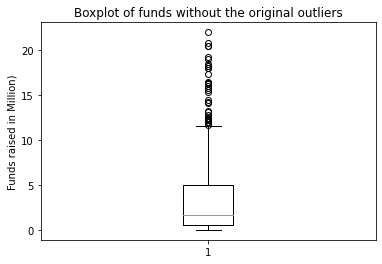

```python
plot = plt.boxplot(startup1['Funds_in_million'])
plt.title('Boxplot of funds without the original outliers')
plt.ylabel("Funds raised in Million)")
plt.show()
```

```python
# Checking the frequency of OperatingState features
startup1['OperatingState'].value_counts()
```

```
Operating    275
Closed        56
Acquired      55
Name: OperatingState, dtype: int64
```

[output not shown]

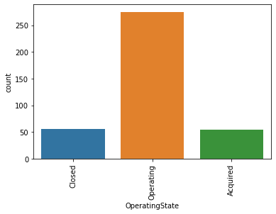

```python
sns.countplot(startup1['OperatingState'])
plt.xticks(rotation=90);
```

[output not shown]

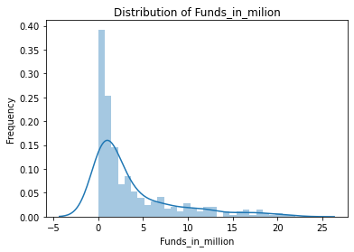

```python
# Plotting a distribution of Funds_in_million
sns.distplot(startup1['Funds_in_million'],bins=30,kde=True)
plt.title('Distribution of Funds_in_milion')
plt.xlabel('Funds_in_million')
plt.ylabel('Frequency')
```

### Statistical Analysis

```python
startup1['Funds_in_million'].describe()
```

```
count    386.00000
mean       3.72514
std        4.73236
min        0.00500
25%        0.60000
50%        1.70000
75%        5.00000
max       22.00000
Name: Funds_in_million, dtype: float64
```

Although the range of values for Funds_in_million are from \$0.005Mn to \\$22.0Mn, 75% of the startups have funding < \$5.0Mn. The data remains skewed despite removing outliers

[output not shown]

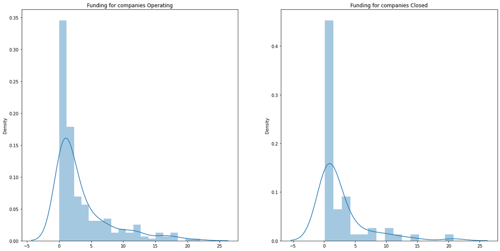

```python
#Plotting the funds distribution for companies Operating and Closed
fig,ax = plt.subplots(1,2)

fig.set_figheight(10)
fig.set_figwidth(20)
sns.distplot(x=startup1[startup1['OperatingState']=='Operating']['Funds_in_million'],ax=ax[0])
sns.distplot(x=startup1[startup1['OperatingState']=='Closed']['Funds_in_million'],ax=ax[1])
ax[0].set_title("Funding for companies Operating")
ax[1].set_title("Funding for companies Closed")
plt.show()
```

The distributions look very similar on the plot. However, to test the statistical significance, we will do a statistical test. We can perform two-sample z or t test here. Also, though the distributions are not normal, since our sample size > 30 we can perform the z-test or t-test.

**Ho =** Null Hypothesis = There is no difference between the two means (mean of funds raised by Operating and Closed)  
**Ha =** Alternate Hypothesis = There is significant difference between the two means

Now, let us perform the z-test on this sample at 0.05 significance level

```python
import scipy.stats as stats
from statsmodels.stats.weightstats import ztest
alpha = 0.05 # defining the significance level
operating = startup1[startup1['OperatingState']=='Operating']['Funds_in_million']
closed = startup1[startup1['OperatingState']=='Closed']['Funds_in_million']
z_stat, p_val = ztest(operating, closed)

if p_val > alpha:
    print("Since p_val = %.3f is greater than the significance level (0.05), the difference between the means is not significant \nand we fail to reject Ho" %p_val)
else:
    print("Since p_val = %.3f is less than the significance level (0.05), the difference between the means is significant \nand we reject Ho" %p_val)
```

```
Since p_val = 0.192 is greater than the significance level (0.05), the difference between the means is not significant
and we fail to reject Ho
```

```python
#Using t-test also gives the same result
from scipy.stats import ttest_ind
t_stat, p_val = ttest_ind(operating, closed)
if p_val > alpha:
    print("Since p_val = %.3f is greater than the significance level (0.05), the difference between the means is not significant \nand we fail to reject Ho" %p_val)
else:
    print("Since p_val = %.3f is less than the significance level (0.05), the difference between the means is significant \nand we reject Ho" %p_val)
```

```
Since p_val = 0.193 is greater than the significance level (0.05), the difference between the means is not significant
and we fail to reject Ho
```

```python
#make a copy of the dataframe
startup2 = startup.copy(deep=True)
startup2.head()
```

|  | Startup | Product | Funding | Event | Result | OperatingState |
| --- | --- | --- | --- | --- | --- | --- |
| 0 | 2600Hz | 2600hz.com | NaN | Disrupt SF 2013 | Contestant | Operating |
| 1 | 3DLT | 3dlt.com | $630K | Disrupt NYC 2013 | Contestant | Closed |
| 2 | 3DPrinterOS | 3dprinteros.com | NaN | Disrupt SF 2016 | Contestant | Operating |
| 3 | 3Dprintler | 3dprintler.com | $1M | Disrupt NY 2016 | Audience choice | Operating |
| 4 | 42 Technologies | 42technologies.com | NaN | Disrupt NYC 2013 | Contestant | Operating |

```python
#Check the frequency distribution of the Result variable
startup2.Result.value_counts()
```

```
Contestant         488
Finalist            84
Audience choice     41
Winner              26
Runner up           23
Name: Result, dtype: int64
```

[output not shown]

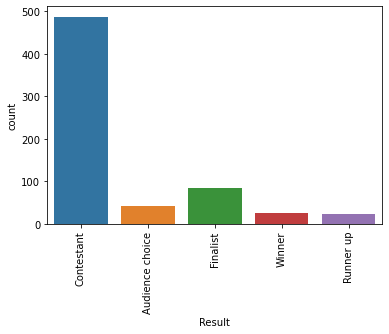

```python
sns.countplot(startup2['Result'])
plt.xticks(rotation=90);
```

There are total 488 firms which were Contestants whie the rest were either Finalists, Audience Choice winners or podium finishers (Winner/Runner up). We can classify all except COntestants as Winners

```python
# Finding proportion of winners and contestants that are in 'Operating' state
n_winners = startup2['Result'].value_counts()[1:].sum() # total number of winners
n_contestants = startup2['Result'].value_counts()[0] # total number of contestants

#startup2.value_counts(["Result", "OperatingState"])
n_w_o = startup2['OperatingState'][startup2['Result']!='Contestant'].value_counts()[0] # total number of winners that are operating
n_c_o = startup2['OperatingState'][startup2['Result']=='Contestant'].value_counts()[0] # total number of contestants that are operating

print ("Proportion of Winners that are Operating is %.3f" %(n_w_o/n_winners))
print ("Proporation of Contestants that are Operating is %.3f" %(n_c_o/n_contestants))
```

```
Proportion of Winners that are Operating is 0.764
Proporation of Contestants that are Operating is 0.680
```

We see that the proportions are different but to determine if they are statistically significantly different, we will do a test of proportions via the z-test or Chi-Square test. Again, we can perform this test as the sample size in each option is > 30

**Ho =** Null Hypothesis = The proportion of companies that are operating is the same in both winners and contestants  
**Ha =** Alternate Hypothesis = The proportion of companies that are operating are statisticaly siginificantly different between winners and contestants

Now, let us perform the z-test on this sample at 0.05 significance level

```python
from statsmodels.stats.proportion import proportions_ztest

z_stat, p_val = proportions_ztest([n_w_o,n_c_o],[n_winners,n_contestants])

if p_val > alpha:
    print("Since p_val = %.3f is greater than the significance level (0.05), the difference between the proportions is not significant \nand we fail to reject Ho" %p_val)
else:
    print("Since p_val = %.3f is less than the significance level (0.05), the difference between the proportions is significant \nand we reject Ho" %p_val)
```

```
Since p_val = 0.037 is less than the significance level (0.05), the difference between the proportions is significant
and we reject Ho
```

```python
# Checking Distribution of Event variable
startup1['Event'].value_counts()
```

```
TC50 2008                    25
TC40 2007                    22
Disrupt NY 2015              21
TC50 2009                    19
Disrupt NYC 2012             19
Disrupt NYC 2013             19
Disrupt SF 2014              19
Disrupt SF 2013              19
Disrupt SF 2011              19
Disrupt SF 2015              19
Disrupt SF 2016              17
Disrupt NY 2016              16
Disrupt NYC 2014             15
Disrupt SF 2012              15
Disrupt NYC 2011             15
Disrupt SF 2010              13
Hardware Battlefield 2016    12
Hardware Battlefield 2014    12
Disrupt London 2015          11
Disrupt EU 2014              10
Disrupt NYC 2010             10
Hardware Battlefield 2015    10
Disrupt London 2016          10
Disrupt EU 2013               9
-                             6
Disrupt Beijing 2011          4
Name: Event, dtype: int64
```

[output not shown]

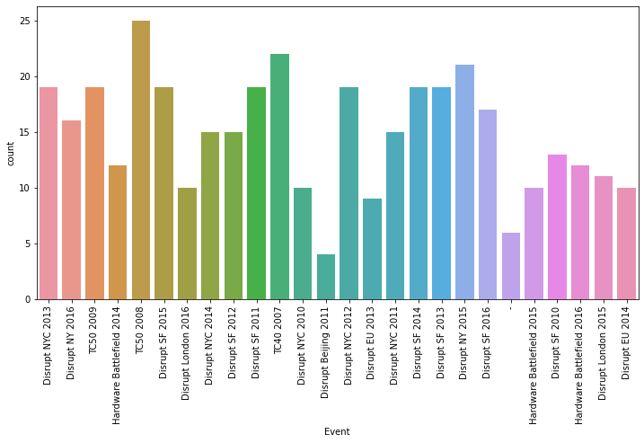

```python
plt.figure(figsize=(12,6))
sns.countplot(startup1['Event'])
plt.xticks(rotation=90);
```

```python
# Picking only the entries with Disrupt keyword in Event and conducted from 2013 onwards
events = startup1[startup1['Event'].apply( lambda x: 'Disrupt' in x and int(x[-4:]) > 2012)]['Event']
year = events.apply(lambda x: int(x[-4:]))
```

```python
NY_eve = startup1.loc[events[events.apply(lambda x: 'NY' in x)].index, 'Funds_in_million']
SF_eve = startup1.loc[events[events.apply(lambda x: 'SF' in x)].index, 'Funds_in_million']
EU_eve = startup1.loc[events[events.apply(lambda x: 'EU' in x or 'London' in x)].index, 'Funds_in_million'] #Assuming London is in EU since the events listed are from a period where UK was still in EU (last year in data is 2016)
```

[output not shown]

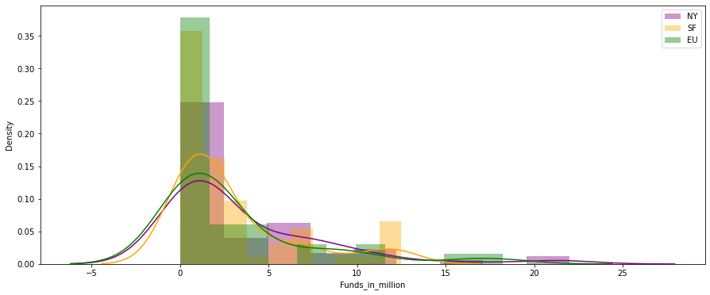

```python
plt.figure(figsize =(15,6))
sns.distplot(NY_eve, color ='purple',label ='NY')
sns.distplot(SF_eve, color ='orange',label ='SF')
sns.distplot(EU_eve, color ='green',label ='EU')
plt.legend()
plt.show()
```

The distributions look quite similar. The mode occurs at pretty much the same spot for all 3 locations. The spread for NY is more than that of SF and EU

```python
print("NY events: %i  SF events: %i  EU events: %i" %(len(NY_eve),len(SF_eve),len(EU_eve)))
```

```
NY events: 71  SF events: 74  EU events: 40
```

We see that there are > 30 samples in each set and hence we can meaningfully perform any statistical tests assuming normal distribution.

**Ho =** Null Hypothesis = Mean of funds raised by companies is same across the 3 locations  
**Ha =** Aternate Hypothesis = Mean of funds raised by companies are different across the 3 locations (atleast one mean is different)

Now, let us perform a One-way ANOVA on this data at 0.05 significance level

```python
from scipy.stats import f_oneway

F_Stat, p_val = f_oneway(NY_eve, SF_eve, EU_eve)

if p_val > alpha:
    print("Since p_val = %.3f is greater than the significance level (0.05), the difference between the means is not significant \nand we fail to reject Ho" %p_val)
else:
    print("Since p_val = %.3f is less than the significance level (0.05), the difference between the means is significant \nand we reject reject Ho" %p_val)
```

```
Since p_val = 0.628 is greater than the significance level (0.05), the difference between the means is not significant
and we fail to reject Ho
```

The distribution of funds raised by the companies across the three regions is the same. There is no evidence to say that the region influences the fund raise (higher or lower).

Summary:  
In this analysis, the objective was to perform analyses and draw statistical conclusions on certain hypotheses. The dataset contains a list of companies along with the product for which funds were raised at various events. The data includes company name, product name, funds raised, event name, competition result and operating state. First, the data set was loaded and entries with missing values for Product and Funding were dropped from the dataset. The funding attribute was skewed and hence the outliers above the upper fence were dropped for further analysis. The funding attribute also had to be standardised in a numerical format for further processing.  
Post data visualization, the aim was to check if there was significant difference between funds raised by companies that were in operating state and closed state. Using z-test at 5% significance level, it was found that there was no significant difference between the two  
Next, the aim was to check if proportion of winners that are operating and proportion of contests that are operating are statistically different. Using two sample z-test at 5% significance level, it weas found that there is indeed statistically significant difference between the two.  
Lastly, the aim was to check if the region of fund raise has any influence on the average funds raised by companies post 2013, among Disrupt events. Using one-way ANOVA at 5% significance level, it was concluded that there was no statistical difference between the mean funds raised between the regions NY, SF and EU.

### Observations on the datapoints collected to perform a better data analysis

**Quality**:

- We had to discard 216 entries due to unavailable data, resulting in a reduced usable data set.
- Pre-processed data will help save time for analysis (such as capturing Event location, Year, and Funds in separate columns and in the right format
- There are 6 event entries still missing which cannot be filled because the year or type of events are not deductible
- Hence, complete data sets would be beneficial to perform statistical analyses
- Specifically, data on the P&L status, employee strength, geographic presence, and a more frequently updated Funding and OperatingState will be helpful

**Quantity**:

- The overall usable data is very low. Hypothesis testing is effective with higher sample sizes. When we apply filtered cuts on the data, the sample size tends to go close to the 30 cut-off, thereby affecting our normality assumptions. Hence, we shoud try to collect more data amongst each cut that we want to analyse that is representative of the population
- In fact, if we want to test our hypothesis on individual Winner classes, it won't be possible since a few have < 30 samples

**Variety**:

- Data from a variety of sources such as blog aritcles, press releases, etc could be tracked to update our database
- Specifically data on P&L statements, Social Media activity/posts from the company, Press Releases and its contents could provide added information on the company's health and funding

**Velocity**:

- The data could be updated every 3 months to ensure the 'OperationsState' and 'Funding' attributes are mapped accurately

**Veracity**:

- The funding values are skewed and abnormal to another 60 outliers which could not be used for analysis. Hence, we should double-check the funding values to ensure the data is truthful and without error

**Value:**

- If we are able to implement the above successfully, we can then add value by being able to predict if a company was about to Close down.
- Movement in company employee strength, shrinkage/expansion in geographic presence can also be used to predict the OperatingState
- Basis their P&L statements and press releases we could also predict their performance in upcoming events